# OchEvo_figs

Michelle Lepori-Bui

11/3/2021

# Ochromonas Evolution Data Analysis

Setup/packages

Data import and wrangling

```r
# Import composite data sheets, change formats, and do some calculations

dat100<-read_csv(here::here("data","OECD100_rev3.csv"))
dat50<-read_csv(here::here("data","OECD50_rev3.csv"))

# experiment time in days days
dat100$Days <- dat100$Week *7
dat50$Days <- dat50$Week *7

#fix import errors
dat100$Chl.a.per.cell <- as.numeric(as.character(dat100$Chl.a.per.cell))
dat100$O2.Count <- as.numeric(as.character(dat100$O2.Count))
dat100$PE.Count <- as.numeric(as.character(dat100$PE.Count))
dat50$Chl.a.per.cell <- as.numeric(as.character(dat50$Chl.a.per.cell))
dat50$O2.Count <- as.numeric(as.character(dat50$O2.Count))
dat50$PE.Count <- as.numeric(as.character(dat50$PE.Count))

# Photosynthesis in O2 per cell per day (12 hours/day of light), Respiration in O2 per cell per day (24 hours/day)

dat100$pgO2.cell.phot.day <- (dat100$pgO2.cell.hr.light-dat100$pgO2.cell.hr.dark)*12
dat100$pgO2.cell.day <- dat100$pgO2.cell.hr.dark*24*-1 # Respiration in O2 per cell per day
dat50$pgO2.cell.phot.day <- (dat50$pgO2.cell.hr.light-dat50$pgO2.cell.hr.dark)*12
dat50$pgO2.cell.day <- dat50$pgO2.cell.hr.dark*24*-1

# convert units from O2 to C later in code, set up calculations for M now
# CN ratio, M (species-specific assimilation quotient from Falkowski et al 1985)
dat100$CN <- dat100$pgC.cell/dat100$pgN.cell
dat50$CN <- dat50$pgC.cell/dat50$pgN.cell
dat100$C_moles <- dat100$pgC.cell * 1e-12 * 0.083259093974539
dat100$N_moles <- dat100$pgN.cell * 1e-12 * 0.071394404106606
dat100$C_N_moles <- dat100$C_moles/dat100$N_moles
dat100$M <- dat100$C_N_moles/(dat100$C_N_moles+2)
dat50$C_moles <- dat50$pgC.cell * 1e-12 * 0.083259093974539
dat50$N_moles <- dat50$pgN.cell * 1e-12 * 0.071394404106606
dat50$C_N_moles <- dat50$C_moles/dat50$N_moles
dat50$M <- dat50$C_N_moles/(dat50$C_N_moles+2)


# mean red fluorescence over 4-day reciprocal transfer exp.
dat100$Mean.redF <- (dat100$Day1.redF + dat100$Day2.redF + dat100$Day3.redF + dat100$Day4.redF) / 4
dat50$Mean.redF <- (dat50$Day1.redF + dat50$Day2.redF + dat50$Day3.redF + dat50$Day4.redF) / 4

# red fluorescence conversion to pg chlorophyll per cell
# these equations come from Jan 2021 Och_AcclimationTempCheck comparing extracted chlorophyll to redf

dat100<- dat100 %>%
  mutate(redF.corr = case_when(
    Strain == "1391" ~ (2.732e-05)*(Mean.redF) + (6.702e-03) ,
    Strain == "2951" ~ (2.652e-05) * (Mean.redF) + (2.353e-02)
  ))
  dat50<- dat50 %>%
  mutate(redF.corr = case_when(
    Strain == "1391" ~ (2.732e-05)*(Mean.redF) + (6.702e-03) ,
    Strain == "2951" ~ (2.652e-05) * (Mean.redF) + (2.353e-02)
  ))


  #Edit: use alpha for attack rate, grazing rate to supplement
# grazing: convert bact per och per day to pgC per och per day
# (pgC/och/day) = grazing rate (bact / och / hr) * 113.5996283 (fgC / bact) * 0.001 pg/fg * 24 (hr/day)
# value averaged from bacteria only CN samples
dat100$graz.day <- dat100$G_O *24 * 113.5996283 * 0.001
dat50$graz.day <- dat50$G_O*24 * 113.5996283 * 0.001

dat100$attack.day <- dat100$graz.alpha *24 *10^5
dat50$attack.day <- dat50$graz.alpha *24 *10^5


# identifiers
dat100$ID <- paste(dat100$Strain,dat100$Ev,dat100$Acc,dat100$Rep,dat100$Week,sep='.')
dat100$Treat <- paste(dat100$Strain,dat100$Ev,dat100$Acc,sep='.')
dat100$Lineage <- paste(dat100$Strain,dat100$Ev,dat100$Acc,dat100$Rep,sep='.')
dat100$Treat.Acc <- paste(dat100$Strain,dat100$Acc,dat100$Rep,dat100$Week,sep='.')

dat50$ID <- paste(dat50$Strain,dat50$Ev,dat50$Acc,dat50$Rep,dat50$Week,sep='.')
dat50$Treat <- paste(dat50$Strain,dat50$Ev,dat50$Acc,sep='.')
dat50$Lineage <- paste(dat50$Strain,dat50$Ev,dat50$Acc,dat50$Rep,sep='.')
dat50$Treat.Acc <- paste(dat50$Strain,dat50$Acc,dat50$Rep,dat50$Week,sep='.')
```

Calculate generations elapsed per treatment based on growth rate and experimental time

```r
# First, create spline of growth rates over time, then calculate

# list for for loops
strain<- c(1391,2951)
temps<- c(18,24,30)

## revised

dat100$doubtime <- 1.520030687
dat100<- dat100 %>%
 mutate(doubtime = case_when(
    Strain == 1391 & Ev == 18|Strain == 1391 & Ev == 24 & Acc ==18  ~ 3.040061373,
      TRUE ~ doubtime))

dat100$days <- dat100$Week * 7
dat100$Generations <- dat100$days / dat100$doubtime

dat50$doubtime <- 1.520030687
dat50<- dat50 %>%
 mutate(doubtime = case_when(
    Strain == 1391 & Ev == 18|Strain == 1391 & Ev == 24 & Acc ==18  ~ 3.040061373,
      TRUE ~ doubtime))

dat50$days <- dat50$Week * 7
dat50$Generations <- dat50$days / dat50$doubtime

 # 100uE
## create dataframe for each treatment with growth rate

# total days of experiment
totdays100 <- max(dat100$Week) *7

for (s in 1:length(strain)){
  for (t in 1:length(temps)) {
    df <- dat100 %>%
      select(Strain, Ev, Acc, Rep, Week, Days, Growth.Rate, Treat) %>%
      filter(Strain == strain[s], Ev == temps[t], Acc == temps[t], !is.na(Growth.Rate))
   assign(paste("gr",strain[s],temps[t],"100",sep = "."), df)
  }
}

## put all treatment dfs into a list
evol.grs.100<-list(gr.1391.18.100=gr.1391.18.100,
               gr.1391.24.100=gr.1391.24.100,
               gr.1391.30.100=gr.1391.30.100,
               gr.2951.18.100=gr.2951.18.100,
               gr.2951.24.100=gr.2951.24.100,
               gr.2951.30.100=gr.2951.30.100)

## create spline for each treatment, calculate to generations elapsed,
 for (i in 1:length(evol.grs.100)) {
   gr.spline<-smooth.spline(evol.grs.100[[i]]$Days,evol.grs.100[[i]]$Growth.Rate,  cv=TRUE)
   spline.result<-as.data.frame(predict(gr.spline,c(0:totdays100),deriv=0))
   spline.result$gens.per.day<- spline.result$y/log(2)
   spline.result$gens.elaps<-cumtrapz(spline.result$x,spline.result$gens.per.day)
   assign(paste("sr.100",evol.grs.100[[i]]$Treat,sep = "."), spline.result)
 }

## repeat for 50 ue
totdays50 <- max(dat50$Week) *7

for (s in 1:length(strain)){
  for (t in 1:length(temps)) {
    df <- dat50 %>%
      select(Strain, Ev, Acc, Rep, Week, Days, Growth.Rate, Treat) %>%
      filter(Strain == strain[s], Ev == temps[t], Acc == temps[t], !is.na(Growth.Rate))
   assign(paste("gr",strain[s],temps[t],"50",sep = "."), df)
  }
}

evol.grs.50<-list(gr.1391.18.50=gr.1391.18.50,
               gr.1391.24.50=gr.1391.24.50,
               gr.1391.30.50=gr.1391.30.50,
               gr.2951.18.50=gr.2951.18.50,
               gr.2951.24.50=gr.2951.24.50,
               gr.2951.30.50=gr.2951.30.50)

 for (i in 1:length(evol.grs.50)) {
   gr.spline<-smooth.spline(evol.grs.50[[i]]$Days,evol.grs.50[[i]]$Growth.Rate,  cv=TRUE)
   spline.result<-as.data.frame(predict(gr.spline,c(0:totdays50),deriv=0))
   spline.result$gens.per.day<- spline.result$y/log(2)
   spline.result$gens.elaps<-cumtrapz(spline.result$x,spline.result$gens.per.day)
   assign(paste("sr.50",evol.grs.50[[i]]$Treat,sep = "."), spline.result)
 }

# treatment-specific generations elapsed
dat100<- dat100 %>%
 mutate(gens.elaps = case_when(
    Strain == 1391 & Ev == 18|Strain == 1391 & Ev == 24 & Acc ==18  ~ sr.100.1391.18.18$gens.elaps[match(dat100$Days,sr.100.1391.18.18$x)],
    Strain == 2951 & Ev == 18|Strain == 2951 & Ev == 24 & Acc ==18  ~ sr.100.2951.18.18$gens.elaps[match(dat100$Days,sr.100.2951.18.18$x)],
    Strain == 1391 & Ev == 30|Strain == 1391 & Ev == 24 & Acc ==30  ~ sr.100.1391.30.30$gens.elaps[match(dat100$Days,sr.100.1391.30.30$x)],
    Strain == 2951 & Ev == 30|Strain == 2951 & Ev == 24 & Acc ==30  ~ sr.100.2951.30.30$gens.elaps[match(dat100$Days,sr.100.2951.30.30$x)],
    Strain == 1391 & Ev == 24 & Acc == 24 ~ sr.100.1391.24.24$gens.elaps[match(dat100$Days,sr.100.1391.24.24$x)],
    Strain == 2951 & Ev == 24 & Acc == 24 ~ sr.100.2951.24.24$gens.elaps[match(dat100$Days,sr.100.2951.24.24$x)]
    ))

dat50<- dat50 %>%
 mutate(gens.elaps = case_when(
    Strain == 1391 & Ev == 18|Strain == 1391 & Ev == 24 & Acc ==18  ~ sr.50.1391.18.18$gens.elaps[match(dat50$Days,sr.50.1391.18.18$x)],
    Strain == 2951 & Ev == 18|Strain == 2951 & Ev == 24 & Acc ==18  ~ sr.50.2951.18.18$gens.elaps[match(dat50$Days,sr.50.2951.18.18$x)],
    Strain == 1391 & Ev == 30|Strain == 1391 & Ev == 24 & Acc ==30  ~ sr.50.1391.30.30$gens.elaps[match(dat50$Days,sr.50.1391.30.30$x)],
    Strain == 2951 & Ev == 30|Strain == 2951 & Ev == 24 & Acc ==30  ~ sr.50.2951.30.30$gens.elaps[match(dat50$Days,sr.50.2951.30.30$x)],
    Strain == 1391 & Ev == 24 & Acc == 24 ~ sr.50.1391.24.24$gens.elaps[match(dat50$Days,sr.50.1391.24.24$x)],
    Strain == 2951 & Ev == 24 & Acc == 24 ~ sr.50.2951.24.24$gens.elaps[match(dat50$Days,sr.50.2951.24.24$x)]
    ))




### rev
dat100$gens.elaps <- dat100$Generations
### rev
dat50$gens.elaps <- dat50$Generations
```

Extract data for specific variables from composite data sheet into their own data frames to compare between treatments:

Growth rate, Red F.C, and FvFm grouped from quarterly backtransfers

Carbon per cell

```r
# data frame for cellular CN content

cn.100 <- as.data.frame(unique(dat100$ID))
names(cn.100) <- 'ID'
cn.100$Treat.Acc <- dat100$Treat.Acc[match(cn.100$ID,dat100$ID)]
cn.100$Lineage <- dat100$Lineage[match(cn.100$ID,dat100$ID)]
cn.100$Strain <- dat100$Strain[match(cn.100$ID,dat100$ID)]
cn.100$Ev <- dat100$Ev[match(cn.100$ID,dat100$ID)]
cn.100$Acc <- dat100$Acc[match(cn.100$ID,dat100$ID)]
cn.100$Rep <- dat100$Rep[match(cn.100$ID,dat100$ID)]
cn.100$Week <- dat100$Week[match(cn.100$ID,dat100$ID)]
cn.100$gens.elaps <- dat100$gens.elaps[match(cn.100$ID,dat100$ID)]
# Match Evolved & ancestral reference points
cn.100$C <- dat100$pgC.cell[match(cn.100$ID,dat100$ID)]
cn.100$C.ref <- dat100[dat100$Ev==24,]$pgC.cell[match(cn.100$Treat.Acc,dat100[dat100$Ev==24,]$Treat.Acc)]
# calculate deltas
cn.100$C.propdel <- (cn.100$C-cn.100$C.ref)/abs(cn.100$C.ref) # Compute rel. difference
cn.100$C.del <- (cn.100$C-cn.100$C.ref) # Compute abs difference
# N
# Match Evolved & ancestral reference points
cn.100$N <- dat100$pgN.cell[match(cn.100$ID,dat100$ID)]
cn.100$N.ref <- dat100[dat100$Ev==24,]$pgN.cell[match(cn.100$Treat.Acc,dat100[dat100$Ev==24,]$Treat.Acc)]
# calculate deltas
cn.100$N.propdel <- (cn.100$N-cn.100$N.ref)/abs(cn.100$N.ref) # Compute rel. difference
cn.100$N.del <- (cn.100$N-cn.100$N.ref) # Compute abs difference
cn.100 <- cn.100[!is.na(cn.100$N),]

# repeat for 50ue
cn.50 <- as.data.frame(unique(dat50$ID))
names(cn.50) <- 'ID'
cn.50$Treat.Acc <- dat50$Treat.Acc[match(cn.50$ID,dat50$ID)]
cn.50$Lineage <- dat50$Lineage[match(cn.50$ID,dat50$ID)]
cn.50$Strain <- dat50$Strain[match(cn.50$ID,dat50$ID)]
cn.50$Ev <- dat50$Ev[match(cn.50$ID,dat50$ID)]
cn.50$Acc <- dat50$Acc[match(cn.50$ID,dat50$ID)]
cn.50$Rep <- dat50$Rep[match(cn.50$ID,dat50$ID)]
cn.50$Week <- dat50$Week[match(cn.50$ID,dat50$ID)]
cn.50$gens.elaps <- dat50$gens.elaps[match(cn.50$ID,dat50$ID)]
# Match evolved & ancestral reference points
cn.50$C <- dat50$pgC.cell[match(cn.50$ID,dat50$ID)]
cn.50$C.ref <- dat50[dat50$Ev==24,]$pgC.cell[match(cn.50$Treat.Acc,dat50[dat50$Ev==24,]$Treat.Acc)]
# calculate deltas
cn.50$C.propdel <- (cn.50$C-cn.50$C.ref)/abs(cn.50$C.ref) # Compute rel. difference
cn.50$C.del <- (cn.50$C-cn.50$C.ref) # Compute abs difference
cn.50 <- cn.50[!is.na(cn.50$C),]

# N
# Match Evolved & ancestral reference points
cn.50$N <- dat50$pgN.cell[match(cn.50$ID,dat50$ID)]
cn.50$N.ref <- dat50[dat50$Ev==24,]$pgN.cell[match(cn.50$Treat.Acc,dat50[dat50$Ev==24,]$Treat.Acc)]
# calculate deltas
cn.50$N.propdel <- (cn.50$N-cn.50$N.ref)/abs(cn.50$N.ref) # Compute rel. difference
cn.50$N.del <- (cn.50$N-cn.50$N.ref) # Compute abs difference
cn.50 <- cn.50[!is.na(cn.50$N),]
```

Respiration and photosynthesis from optode in pgC/pgC per day == gC per gC per day

Grazing using alpha / attack rate in main text

Grazing in pgC per pgC per day == gC per gC per day (for supplement)

Carbon use efficiency

```r
# calculate carbon use efficiency end of experiment data points for growth rate and respiration
# cue = net carbon gained/gross carbon gained = growth / (growth + respiration)

# 100uE CUE
CUE100_last3 <- growths100 %>%
  filter(Strain != 1393) %>%
  filter(Week %in% c(125,140,154))
CUE100_last3$pgC.cell <- cn_hold100$pgC.cell[match(CUE100_last3$Lineage,cn_hold100$Lineage)]
CUE100_last3$gr.cell <- CUE100_last3$pgC.cell * CUE100_last3$Growth.Rate
# average growth and and respiration to calculate average cue
cue.gr.avg.100 <- summarySE(data = CUE100_last3, measurevar = 'gr.cell', groupvars = c('Strain', 'Ev', 'Acc', 'Rep'))
cue.gr.avg.100$ID <- paste(cue.gr.avg.100$Strain, cue.gr.avg.100$Ev, cue.gr.avg.100$Acc, cue.gr.avg.100$Rep, sep = ".")
cue.resp.avg.100 <- summarySE(data = resp.100, measurevar = 'Resp', groupvars = c('Strain', 'Ev', 'Acc', 'Rep'))
cue.resp.avg.100$ID <- paste(cue.resp.avg.100$Strain, cue.resp.avg.100$Ev, cue.resp.avg.100$Acc, cue.resp.avg.100$Rep, sep = ".")
cue.gr.avg.100$Resp.avg <- cue.resp.avg.100$Resp[match(cue.gr.avg.100$ID,cue.resp.avg.100$ID)]
cue.gr.avg.100$CUE <- cue.gr.avg.100$gr.cell / (cue.gr.avg.100$gr.cell + cue.gr.avg.100$Resp.avg)

# repeat for 50 ue
CUE50_last3 <- growths50 %>%
  filter(Strain != 1393) %>%
  filter(Week %in% c(125,140,154))
CUE50_last3$pgC.cell <- cn_hold50$pgC.cell[match(CUE50_last3$Lineage,cn_hold50$Lineage)]
CUE50_last3$gr.cell <- CUE50_last3$pgC.cell * CUE50_last3$Growth.Rate
cue.gr.avg.50 <- summarySE(data = CUE50_last3, measurevar = 'gr.cell', groupvars = c('Strain', 'Ev', 'Acc', 'Rep'))
cue.gr.avg.50$ID <- paste(cue.gr.avg.50$Strain, cue.gr.avg.50$Ev, cue.gr.avg.50$Acc, cue.gr.avg.50$Rep, sep = ".")
cue.resp.avg.50 <- summarySE(data = resp.50, measurevar = 'Resp', groupvars = c('Strain', 'Ev', 'Acc', 'Rep'))
cue.resp.avg.50$ID <- paste(cue.resp.avg.50$Strain, cue.resp.avg.50$Ev, cue.resp.avg.50$Acc, cue.resp.avg.50$Rep, sep = ".")
cue.gr.avg.50$Resp.avg <- cue.resp.avg.50$Resp[match(cue.gr.avg.50$ID,cue.resp.avg.50$ID)]
cue.gr.avg.50$CUE <- cue.gr.avg.50$gr.cell / (cue.gr.avg.50$gr.cell + cue.gr.avg.50$Resp.avg)
```

### Growth rate TIMESERIES

T-testing

```r
# ttest for growth rate delta difference from 0

# TTEST FOR LOOP
ttest.df.100 <- growths100 %>%
  filter(Strain != 1393) %>%
  select( ID, Strain, Ev, Acc, Rep, Week, gens.elaps, Growth.del) %>%
  filter(Ev==Acc) %>%
  filter(Ev != 24)
ttest.df.100$group <- paste(ttest.df.100$Strain,ttest.df.100$Ev,ttest.df.100$Acc,ttest.df.100$Week,sep='.')
#data frame to store results
pvals.df.100 <- as.data.frame(unique(ttest.df.100$group))
names(pvals.df.100) <- 'group'
pvals.df.100$Strain <- ttest.df.100$Strain[match(pvals.df.100$group,ttest.df.100$group)]
pvals.df.100$Ev <- ttest.df.100$Ev[match(pvals.df.100$group,ttest.df.100$group)]
pvals.df.100$Acc <- ttest.df.100$Acc[match(pvals.df.100$group,ttest.df.100$group)]
pvals.df.100$Week <- ttest.df.100$Week[match(pvals.df.100$group,ttest.df.100$group)]
pvals.df.100$gens.elaps <- ttest.df.100$gens.elaps[match(pvals.df.100$group,ttest.df.100$group)]
pvals.df.100$p.value <- NA

for(i in 1:dim(pvals.df.100)[1]){
  hold <-ttest.df.100[ttest.df.100$group==pvals.df.100$group[i],] %>%
    pull(Growth.del)
  hold.ttest <- t.test(hold)
  tidy.hold <- tidy(hold.ttest)
  pvals.df.100$p.value[i] <- tidy.hold$p.value }

pvals.df.100 <- pvals.df.100 %>%
  mutate(signif.alpha = case_when(
    pvals.df.100$p.value <= .001 ~ 1,
    pvals.df.100$p.value >.001 & pvals.df.100$p.value <= .01 ~ .75,
    pvals.df.100$p.value > .01 & pvals.df.100$p.value <= .05 ~ .5,
    pvals.df.100$p.value > .05 ~ 0
  ))


# repeat for 50 uE
# TTEST FOR LOOP
ttest.df.50 <- growths50 %>%
  filter(Strain != 1393) %>%
  select( ID, Strain, Ev, Acc, Rep, Week, gens.elaps, Growth.del) %>%
  filter(Ev==Acc) %>%
  filter(Ev != 24)
ttest.df.50$group <- paste(ttest.df.50$Strain,ttest.df.50$Ev,ttest.df.50$Acc,ttest.df.50$Week,sep='.')
# data frame to store results
pvals.df.50 <- as.data.frame(unique(ttest.df.50$group))
names(pvals.df.50) <- 'group'
pvals.df.50$Strain <- ttest.df.50$Strain[match(pvals.df.50$group,ttest.df.50$group)]
pvals.df.50$Ev <- ttest.df.50$Ev[match(pvals.df.50$group,ttest.df.50$group)]
pvals.df.50$Acc <- ttest.df.50$Acc[match(pvals.df.50$group,ttest.df.50$group)]
pvals.df.50$Week <- ttest.df.50$Week[match(pvals.df.50$group,ttest.df.50$group)]
pvals.df.50$gens.elaps <- ttest.df.50$gens.elaps[match(pvals.df.50$group,ttest.df.50$group)]
pvals.df.50$p.value <- NA

for(i in 1:dim(pvals.df.50)[1]){
  hold <-ttest.df.50[ttest.df.50$group==pvals.df.50$group[i],] %>%
    pull(Growth.del)
  hold.ttest <- t.test(hold)
  tidy.hold <- tidy(hold.ttest)
  pvals.df.50$p.value[i] <- tidy.hold$p.value }

pvals.df.50 <- pvals.df.50 %>%
  mutate(signif.alpha = case_when(
    pvals.df.50$p.value <= .001 ~ 1,
    pvals.df.50$p.value >.001 & pvals.df.50$p.value <= .01 ~ .75,
    pvals.df.50$p.value > .01 & pvals.df.50$p.value <= .05 ~ .5,
    pvals.df.50$p.value > .05 ~ 0
  ))
```

Timeseries plot - alpha pvals

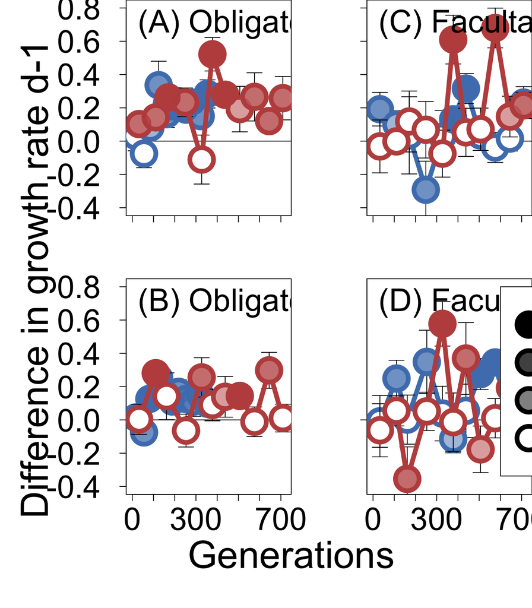

```r
Growth.summ.100 <- summarySE(data=growths100,measurevar='Growth.Rate',groupvars=c('Strain','Ev','Acc','gens.elaps','Week'))
Del.Growth.summ.100 <- summarySE(data=growths100,measurevar='Growth.del',groupvars=c('Strain','Ev','Acc','gens.elaps','Week'))

Growth.summ.50 <- summarySE(data=growths50,measurevar='Growth.Rate',groupvars=c('Strain','Ev','Acc','gens.elaps','Week'))
Del.Growth.summ.50 <- summarySE(data=growths50,measurevar='Growth.del',groupvars=c('Strain','Ev','Acc','gens.elaps', 'Week'))



par(mar=c(5,6,0,0),mgp=c(3,2,0),mfrow=c(2,2),oma=c(4,4,0,0))

ptcex <- 5
labelcex <- 3
lwdset<- 6
maincex <- 3

# for legend
lp1<- expression(italic(p) < 0.001 )
lp2<- expression(italic(p) < 0.01 )
lp3<- expression(italic(p) < 0.05 )
lp4<- expression(italic(p) > 0.05 )

xtick<- seq(0,800, by=100)
ytick<-seq(-.4,.8, by=.2)

## 1391 100
strainchoice <- 1391
tempchoice <- 18
del <- Del.Growth.summ.100[Del.Growth.summ.100$Strain==strainchoice & Del.Growth.summ.100$Acc==tempchoice & Del.Growth.summ.100$Ev==Del.Growth.summ.100$Acc,]
del$group <- paste(del$Strain,del$Ev,del$Acc,del$Week,sep='.')
del$signif <- pvals.df.100$signif[match(del$group,pvals.df.100$group)]
del$signif.val <- pvals.df.100$signif.val[match(del$group,pvals.df.100$group)]
del$signif.alpha <- pvals.df.100$signif.alpha[match(del$group,pvals.df.100$group)]

plot(del$gens.elaps,del$Growth.del,ylim=c(-.4,.8),type='n',ylab='',xlab='',xaxt = 'n', las=1,xlim=c(0,720),cex.lab=labelcex,cex.axis=labelcex,cex.main=maincex);
axis(side=1, at=xtick, labels = FALSE);
abline(h=0); lines(del$gens.elaps,del$Growth.del,col=lcol2,lwd=lwdset); arrows(del$gens.elaps,del$Growth.del+del$sd,del$gens.elaps,del$Growth.del-del$sd,code=3,length=.1,angle=90);
points(del$gens.elaps,del$Growth.del,pch=21,col = lcol2,bg = "white", cex=ptcex, lwd = lwdset); points(del$gens.elaps,del$Growth.del,pch=19,col = alpha(lcol2, alpha = del$signif.alpha),cex=ptcex)
# text(del$gens.elaps, .7,  del$signif,
#      cex=5,col=lcol2,srt=-90, pos=1)

tempchoice <- 30
del <- Del.Growth.summ.100[Del.Growth.summ.100$Strain==strainchoice & Del.Growth.summ.100$Acc==tempchoice & Del.Growth.summ.100$Ev==Del.Growth.summ.100$Acc,]
del$group <- paste(del$Strain,del$Ev,del$Acc,del$Week,sep='.')
del$signif <- pvals.df.100$signif[match(del$group,pvals.df.100$group)]
del$signif.val <- pvals.df.100$signif.val[match(del$group,pvals.df.100$group)]
del$signif.alpha <- pvals.df.100$signif.alpha[match(del$group,pvals.df.100$group)]

arrows(del$gens.elaps,del$Growth.del+del$sd,del$gens.elaps,del$Growth.del-del$sd,code=3,length=.1,angle=90); lines(del$gens.elaps,del$Growth.del,col=hcol2,lwd=lwdset); points(del$gens.elaps,del$Growth.del,pch=21,col = hcol2,bg = "white", cex=ptcex, lwd = lwdset)
points(del$gens.elaps,del$Growth.del,pch=19,col = alpha(hcol2, alpha = del$signif.alpha),cex=ptcex)
text(-3,.7,'(A) Obligate, high light',cex=labelcex,pos=4)
# text(del$gens.elaps, .7,  del$signif,
#      cex=5,col=hcol2,srt=-90, pos=1)

## 2951 100
strainchoice <- 2951
tempchoice <- 18
del <- Del.Growth.summ.100[Del.Growth.summ.100$Strain==strainchoice & Del.Growth.summ.100$Acc==tempchoice & Del.Growth.summ.100$Ev==Del.Growth.summ.100$Acc,]
del$group <- paste(del$Strain,del$Ev,del$Acc,del$Week,sep='.')
del$signif <- pvals.df.100$signif[match(del$group,pvals.df.100$group)]
del$signif.val <- pvals.df.100$signif.val[match(del$group,pvals.df.100$group)]
del$signif.alpha <- pvals.df.100$signif.alpha[match(del$group,pvals.df.100$group)]
xtick <- seq(0,800, by = 100)
plot(del$gens.elaps,del$Growth.del,ylim=c(-.4,.8),type='n',ylab='',xlab='',xaxt = 'n', yaxt = 'n', las=1,xlim=c(0,720),cex.lab=labelcex,cex.axis=labelcex,cex.main=maincex); abline(h=0);
axis(side=1, at=xtick, labels = FALSE);
axis(side=2, at=ytick, labels = FALSE);
lines(del$gens.elaps,del$Growth.del,col=lcol2,lwd=lwdset); arrows(del$gens.elaps,del$Growth.del+del$sd,del$gens.elaps,del$Growth.del-del$sd,code=3,length=.1,angle=90);
points(del$gens.elaps,del$Growth.del,pch=21,col = lcol2,bg = "white", cex=ptcex, lwd = lwdset)
points(del$gens.elaps,del$Growth.del,pch=19,col = alpha(lcol2, alpha = del$signif.alpha),cex=ptcex)
# text(del$gens.elaps, .7,  del$signif,
#      cex=5,col=lcol2,srt=-90, pos=1)

tempchoice <- 30
del <- Del.Growth.summ.100[Del.Growth.summ.100$Strain==strainchoice & Del.Growth.summ.100$Acc==tempchoice & Del.Growth.summ.100$Ev==Del.Growth.summ.100$Acc,]
del$group <- paste(del$Strain,del$Ev,del$Acc,del$Week,sep='.')
del$signif <- pvals.df.100$signif[match(del$group,pvals.df.100$group)]
del$signif.val <- pvals.df.100$signif.val[match(del$group,pvals.df.100$group)]
del$signif.alpha <- pvals.df.100$signif.alpha[match(del$group,pvals.df.100$group)]

arrows(del$gens.elaps,del$Growth.del+del$sd,del$gens.elaps,del$Growth.del-del$sd,code=3,length=.1,angle=90); lines(del$gens.elaps,del$Growth.del,col=hcol2,lwd=lwdset); points(del$gens.elaps,del$Growth.del,pch=21,col = hcol2,bg = "white", cex=ptcex, lwd = lwdset)
points(del$gens.elaps,del$Growth.del,pch=19,col = alpha(hcol2, alpha = del$signif.alpha),cex=ptcex)
# text(del$gens.elaps, .7,  del$signif,
#      cex=5,col=hcol2,srt=-90, pos=1)
text(-3,.7,'(C) Facultative, high light',cex=labelcex,pos=4)


## 1391 50
strainchoice <- 1391
tempchoice <- 18
del <- Del.Growth.summ.50[Del.Growth.summ.50$Strain==strainchoice & Del.Growth.summ.50$Acc==tempchoice & Del.Growth.summ.50$Ev==Del.Growth.summ.50$Acc,]
del$group <- paste(del$Strain,del$Ev,del$Acc,del$Week,sep='.')
del$signif <- pvals.df.50$signif[match(del$group,pvals.df.50$group)]
del$signif.val <- pvals.df.50$signif.val[match(del$group,pvals.df.50$group)]
del$signif.alpha <- pvals.df.50$signif.alpha[match(del$group,pvals.df.50$group)]

plot(del$gens.elaps,del$Growth.del,ylim=c(-.4,.8),type='n',ylab='',xlab='',las=1,xlim=c(0,720),cex.lab=labelcex,cex.axis=labelcex,cex.main=maincex); abline(h=0); lines(del$gens.elaps,del$Growth.del,col=lcol2,lwd=lwdset); arrows(del$gens.elaps,del$Growth.del+del$sd,del$gens.elaps,del$Growth.del-del$sd,code=3,length=.1,angle=90);
points(del$gens.elaps,del$Growth.del,pch=21,col = lcol2,bg = "white", cex=ptcex, lwd = lwdset)
points(del$gens.elaps,del$Growth.del,pch=19,col = alpha(lcol2, alpha = del$signif.alpha),cex=ptcex)
# text(del$gens.elaps, .7,  del$signif,
#      cex=5,col=lcol2,srt=-90, pos=1)

tempchoice <- 30
del <- Del.Growth.summ.50[Del.Growth.summ.50$Strain==strainchoice & Del.Growth.summ.50$Acc==tempchoice & Del.Growth.summ.50$Ev==Del.Growth.summ.50$Acc,]
del$group <- paste(del$Strain,del$Ev,del$Acc,del$Week,sep='.')
del$signif <- pvals.df.50$signif[match(del$group,pvals.df.50$group)]
del$signif.val <- pvals.df.50$signif.val[match(del$group,pvals.df.50$group)]
del$signif.alpha <- pvals.df.50$signif.alpha[match(del$group,pvals.df.50$group)]

arrows(del$gens.elaps,del$Growth.del+del$sd,del$gens.elaps,del$Growth.del-del$sd,code=3,length=.1,angle=90); lines(del$gens.elaps,del$Growth.del,col=hcol2,lwd=lwdset); points(del$gens.elaps,del$Growth.del,pch=21,col = hcol2,bg = "white", cex=ptcex, lwd = lwdset)
points(del$gens.elaps,del$Growth.del,pch=19,col = alpha(hcol2, alpha = del$signif.alpha),cex=ptcex)
text(-3,.7,'(B) Obligate, low light',cex=labelcex,pos=4)
# text(del$gens.elaps, .7,  del$signif,
#      cex=5,col=hcol2,srt=-90, pos=1)

## 2951 50
strainchoice <- 2951
tempchoice <- 18
del <- Del.Growth.summ.50[Del.Growth.summ.50$Strain==strainchoice & Del.Growth.summ.50$Acc==tempchoice & Del.Growth.summ.50$Ev==Del.Growth.summ.50$Acc,]
del$group <- paste(del$Strain,del$Ev,del$Acc,del$Week,sep='.')
del$signif <- pvals.df.50$signif[match(del$group,pvals.df.50$group)]
del$signif.val <- pvals.df.50$signif.val[match(del$group,pvals.df.50$group)]
del$signif.alpha <- pvals.df.50$signif.alpha[match(del$group,pvals.df.50$group)]
ytick <- seq(0,1300,by=200)
plot(del$gens.elaps,del$Growth.del,ylim=c(-.4,.8),type='n',ylab='',xlab='',yaxt = 'n',
      las=1,xlim=c(0,720),cex.lab=labelcex,cex.axis=labelcex,cex.main=maincex);
axis(side=2, at=ytick, labels = FALSE);
abline(h=0); lines(del$gens.elaps,del$Growth.del,col=lcol2,lwd=lwdset);
arrows(del$gens.elaps,del$Growth.del+del$sd,del$gens.elaps,del$Growth.del-del$sd,code=3,length=.1,angle=90);
points(del$gens.elaps,del$Growth.del,pch=21,col = lcol2,bg = "white", cex=ptcex, lwd = lwdset)
points(del$gens.elaps,del$Growth.del,pch=19,col = alpha(lcol2, alpha = del$signif.alpha),cex=ptcex)
# text(del$gens.elaps, .7,  del$signif,
#      cex=5,col=lcol2,srt=-90, pos=1)

tempchoice <- 30
del <- Del.Growth.summ.50[Del.Growth.summ.50$Strain==strainchoice & Del.Growth.summ.50$Acc==tempchoice & Del.Growth.summ.50$Ev==Del.Growth.summ.50$Acc,]
del$group <- paste(del$Strain,del$Ev,del$Acc,del$Week,sep='.')
del$signif <- pvals.df.50$signif[match(del$group,pvals.df.50$group)]
del$signif.val <- pvals.df.50$signif.val[match(del$group,pvals.df.50$group)]
del$signif.alpha <- pvals.df.50$signif.alpha[match(del$group,pvals.df.50$group)]

arrows(del$gens.elaps,del$Growth.del+del$sd,del$gens.elaps,del$Growth.del-del$sd,code=3,length=.1,angle=90);
lines(del$gens.elaps,del$Growth.del,col=hcol2,lwd=lwdset); points(del$gens.elaps,del$Growth.del,pch=21,col = hcol2,bg = "white", cex=ptcex, lwd = lwdset)
points(del$gens.elaps,del$Growth.del,pch=19,col = alpha(hcol2, alpha = del$signif.alpha),cex=ptcex)
text(-3,.7,'(D) Facultative, low light',cex=labelcex,pos=4)
# text(del$gens.elaps, .7,  del$signif,
#      cex=5,col=hcol2,srt=-90, pos=1)

legend(600,0.8, legend = c(lp1,lp2,lp3,lp4), pch= c(21,21,21,21),col = "black", pt.bg = alpha("black", alpha = c(1,.75,.5,0)), pt.cex = ptcex, pt.lwd = lwdset, cex = labelcex )


mtext("Generations",side=1,line=0,outer=TRUE,cex=labelcex)
mtext("Difference in growth rate d-1",side=2,line=0,outer=TRUE,cex=labelcex,las=0)
```

```r
#"p<0.001","p<0.01","p<0.05","p>.05"
```

Figure 2. Thermal adaptation in obligate phototrophs. To test for evolutionary responses, we computed the difference in growth rates between experimental and acclimated control lineages at hot (red) and cold (blue) temperatures. Positive values are evidence of adaptive evolution (experimental lineages growing faster than acclimated control lineages assayed at the same temperature). The x-axes are scaled by growth rate to show time in number of generations the evolving strains experienced at their evolutionary temperatures. Data are shown for both mixotroph strains—the obligate phototroph Strain 1391 (left column) and the facultative phototroph Strain 2951 (right column) – and both light levels – high light (100 μmol quanta·m−2·s−1 top row) and low light (50 μmol quanta·m−2·s−1, bottom row) for each reciprocal transplant experiment. Point coloration indicates significance ranging from p<0.001 (darkest points; one sample Student’s t-test) to p>0.05 (white).

### End of experiment evolutionary vs plastic responses

Summary stats for all parameters for last 2-3 measurements timepoints

```r
# Calculate summary stats at end of experiment

# growth, redf, fvfm
# 100 uE
growthsweekselection <- c(125,140,154)
growths100_last3<- growths100 %>%
  filter(Strain != 1393) %>%
  filter(Week %in% growthsweekselection)
Growth.summ.100 <- summarySE(data=growths100_last3,measurevar='Growth.Rate',groupvars=c('Strain','Ev','Acc'))
Del.Growth.summ.100 <- summarySE(data=growths100_last3,measurevar='Growth.del',groupvars=c('Strain','Ev','Acc'))
redf.summ.100 <- summarySE(data=growths100_last3,measurevar='redf',groupvars=c('Strain','Ev','Acc'))
Del.redf.summ.100 <- summarySE(data=growths100_last3,measurevar='redf.del',groupvars=c('Strain','Ev','Acc'))
fvfm.summ.100 <- summarySE(data=growths100_last3,measurevar='fvfm',groupvars=c('Strain','Ev','Acc'))
Del.fvfm.summ.100 <- summarySE(data=growths100_last3,measurevar='fvfm.del',groupvars=c('Strain','Ev','Acc'))

fsc.summ.100 <- summarySE(data=growths100_last3,measurevar='fsc',groupvars=c('Strain','Ev','Acc'))
Del.fsc.summ.100 <- summarySE(data=growths100_last3,measurevar='fsc.del',groupvars=c('Strain','Ev','Acc'))


# 50uE
growths50_last3<-growths50 %>%
  filter(Strain != 1393) %>%
  filter(Week %in% growthsweekselection)
Growth.summ.50 <- summarySE(data=growths50_last3,measurevar='Growth.Rate',groupvars=c('Strain','Ev','Acc'))
redf.summ.50 <- summarySE(data=growths50_last3,measurevar='redf',groupvars=c('Strain','Ev','Acc'))
fvfm.summ.50 <- summarySE(data=growths50_last3,measurevar='fvfm',groupvars=c('Strain','Ev','Acc'))
Del.fvfm.summ.50 <- summarySE(data=growths50_last3,measurevar='fvfm.del',groupvars=c('Strain','Ev','Acc'))

fsc.summ.50 <- summarySE(data=growths50_last3,measurevar='fsc',groupvars=c('Strain','Ev','Acc'))
Del.fsc.summ.50 <- summarySE(data=growths50_last3,measurevar='fsc.del',groupvars=c('Strain','Ev','Acc'))

# cn
cn.100_last3<-cn.100 %>%
  filter(Strain != 1393) %>%
  filter(Week %in% c(104,141))
C.summ.100 <- summarySE(data=cn.100_last3,measurevar='C',groupvars=c('Strain','Ev','Acc'))
cn.50_last3<-cn.50 %>%
  filter(Strain != 1393) %>%
  filter(Week %in% c(104,141))
C.summ.50 <- summarySE(data=cn.50_last3,measurevar='C',groupvars=c('Strain','Ev','Acc'))
N.summ.100 <- summarySE(data=cn.100_last3,measurevar='N',groupvars=c('Strain','Ev','Acc'))
N.summ.50 <- summarySE(data=cn.50_last3,measurevar='N',groupvars=c('Strain','Ev','Acc'))
N.summ.100.2<- N.summ.100[,c(1,2,3,5,6,7,8)]
N.summ.50.2<- N.summ.50[,c(1,2,3,5,6,7,8)]

# respiration and photosynthesis
resp.100_last3<-resp.100 %>%
  filter(Strain != 1393) %>%
  filter(Week %in% c(90,114,138))
Resp.summ.100 <- summarySE(data=resp.100_last3,measurevar='Resp',groupvars=c('Strain','Ev','Acc'))
Photo.summ.100 <- summarySE(data=resp.100_last3,measurevar='Photo',groupvars=c('Strain','Ev','Acc'))
resp.50_last3<-resp.50 %>%
  filter(Strain != 1393) %>%
  filter(Week %in% c(90,114,138))
Resp.summ.50 <- summarySE(data=resp.50_last3,measurevar='Resp',groupvars=c('Strain','Ev','Acc'))
Photo.summ.50 <- summarySE(data=resp.50_last3,measurevar='Photo',groupvars=c('Strain','Ev','Acc'))

# attack rate
attack100_last3<-attack.100 %>%
  filter(Strain != 1393) %>%
  filter(Week %in% c(118,130,142))
Attack.summ.100 <- summarySE(data=attack100_last3,measurevar='attack',groupvars=c('Strain','Ev','Acc'))
attack50_last3<-attack.50 %>%
  filter(Strain != 1393) %>%
  filter(Week %in% c(118,130,142))
Attack.summ.50 <- summarySE(data=attack50_last3,measurevar='attack',groupvars=c('Strain','Ev','Acc'))

# grazing
graz100_last3<-graz.100 %>%
  filter(Strain != 1393) %>%
  filter(Week %in% c(118,130,142))
Graz.summ.100 <- summarySE(data=graz100_last3,measurevar='graz',groupvars=c('Strain','Ev','Acc'))
graz50_last3<-graz.50 %>%
  filter(Strain != 1393) %>%
  filter(Week %in% c(118,130,142))
Graz.summ.50 <- summarySE(data=graz50_last3,measurevar='graz',groupvars=c('Strain','Ev','Acc'))

# CUE
CUE.summ.100<- summarySE(data=cue.gr.avg.100,measurevar='CUE',groupvars=c('Strain','Ev','Acc'))
CUE.summ.50<- summarySE(data=cue.gr.avg.50,measurevar='CUE',groupvars=c('Strain','Ev','Acc'))
```

T-testing for Fig 3

```r
# test the difference between evolved and acclimates with two sample ttests
# 100
ttest.df.100.3 <- growths100_last3 %>%
  filter(Strain != 1393) %>%
  select( ID, Strain, Ev, Acc, Rep, Week, Growth.Rate, Growth.Rate.ref,redf,redf.ref,fvfm,fvfm.ref,fsc,fsc.ref) %>%
  filter(Ev==Acc) %>%
  filter(Ev != 24)
ttest.df.100.3$group <- paste(ttest.df.100.3$Strain,ttest.df.100.3$Ev,ttest.df.100.3$Acc,sep='.')
# set up df to save results
pvals.df.100.3 <- as.data.frame(unique(ttest.df.100.3$group))
names(pvals.df.100.3) <- 'group'
pvals.df.100.3$Strain <- ttest.df.100.3$Strain[match(pvals.df.100.3$group,ttest.df.100.3$group)]
pvals.df.100.3$Ev <- ttest.df.100.3$Ev[match(pvals.df.100.3$group,ttest.df.100.3$group)]
pvals.df.100.3$Acc <- ttest.df.100.3$Acc[match(pvals.df.100.3$group,ttest.df.100.3$group)]
pvals.df.100.3$p.value.growth <- NA
pvals.df.100.3$p.value.redf <- NA
pvals.df.100.3$p.value.fvfm <- NA
pvals.df.100.3$p.value.fsc <- NA

#GR 2 sample
for(i in 1:dim(pvals.df.100.3)[1]){
  hold1 <-ttest.df.100.3[ttest.df.100.3$group==pvals.df.100.3$group[i],] %>%
    pull(Growth.Rate)
   hold2 <-ttest.df.100.3[ttest.df.100.3$group==pvals.df.100.3$group[i],] %>%
    pull(Growth.Rate.ref)
  hold.ttest <- t.test(hold1,hold2)
  tidy.hold <- tidy(hold.ttest)
  pvals.df.100.3$p.value.growth[i] <- round(tidy.hold$p.value,3) }
# REDF
for(i in 1:dim(pvals.df.100.3)[1]){
  hold1 <-ttest.df.100.3[ttest.df.100.3$group==pvals.df.100.3$group[i],] %>%
    pull(redf)
  hold2 <-ttest.df.100.3[ttest.df.100.3$group==pvals.df.100.3$group[i],] %>%
    pull(redf.ref)
  hold.ttest <- t.test(hold1, hold2)
  tidy.hold <- tidy(hold.ttest)
  pvals.df.100.3$p.value.redf[i] <- round(tidy.hold$p.value,3) }
#FVFM
for(i in 1:dim(pvals.df.100.3)[1]){
  hold1 <-ttest.df.100.3[ttest.df.100.3$group==pvals.df.100.3$group[i],] %>%
    pull(fvfm)
   hold2 <-ttest.df.100.3[ttest.df.100.3$group==pvals.df.100.3$group[i],] %>%
    pull(fvfm.ref)
   hold.ttest <- t.test(hold1, hold2)
  tidy.hold <- tidy(hold.ttest)
  pvals.df.100.3$p.value.fvfm[i] <- round(tidy.hold$p.value,3) }

#FSC
for(i in 1:dim(pvals.df.100.3)[1]){
  hold1 <-ttest.df.100.3[ttest.df.100.3$group==pvals.df.100.3$group[i],] %>%
    pull(fsc)
   hold2 <-ttest.df.100.3[ttest.df.100.3$group==pvals.df.100.3$group[i],] %>%
    pull(fsc.ref)
   hold.ttest <- t.test(hold1, hold2)
  tidy.hold <- tidy(hold.ttest)
  pvals.df.100.3$p.value.fsc[i] <- round(tidy.hold$p.value,3) }


## CN
ttest.df.100.cn <- cn.100_last3 %>%
  filter(Strain != 1393) %>%
  select( ID, Strain, Ev, Acc, Rep, Week, C, C.ref, N, N.ref) %>%
  filter(Ev==Acc) %>%
  filter(Ev != 24)
ttest.df.100.cn$group <- paste(ttest.df.100.cn$Strain,ttest.df.100.cn$Ev,ttest.df.100.cn$Acc,sep='.')
pvals.df.100.3$p.value.c <- NA
#C
for(i in 1:dim(pvals.df.100.3)[1]){
  hold1 <-ttest.df.100.cn[ttest.df.100.cn$group==pvals.df.100.3$group[i],] %>%
    pull(C)
  hold2 <-ttest.df.100.cn[ttest.df.100.cn$group==pvals.df.100.3$group[i],] %>%
    pull(C.ref)
  hold.ttest <- t.test(hold1, hold2)
  tidy.hold <- tidy(hold.ttest)
  pvals.df.100.3$p.value.c[i] <- round(tidy.hold$p.value,3) }

## Respirometry
ttest.df.100.resp <- resp.100_last3 %>%
  filter(Strain != 1393) %>%
  select( ID, Strain, Ev, Acc, Rep, Week, Resp, Resp.ref, Photo, Photo.ref) %>%
  filter(Ev==Acc) %>%
  filter(Ev != 24) %>%
  filter(!is.na(Resp.ref))
ttest.df.100.resp$group <- paste(ttest.df.100.resp$Strain,ttest.df.100.resp$Ev,ttest.df.100.resp$Acc,sep='.')
pvals.df.100.3$p.value.resp <- NA
pvals.df.100.3$p.value.photo <- NA
# resp
for(i in 1:dim(pvals.df.100.3)[1]){
  hold1 <-ttest.df.100.resp[ttest.df.100.resp$group==pvals.df.100.3$group[i],] %>%
    pull(Resp)
  hold2 <-ttest.df.100.resp[ttest.df.100.resp$group==pvals.df.100.3$group[i],] %>%
    pull(Resp.ref)
  hold.ttest <- t.test(hold1, hold2)
  tidy.hold <- tidy(hold.ttest)
  pvals.df.100.3$p.value.resp[i] <- round(tidy.hold$p.value,3) }
# photo
for(i in 1:dim(pvals.df.100.3)[1]){
  hold1 <-ttest.df.100.resp[ttest.df.100.resp$group==pvals.df.100.3$group[i],] %>%
    pull(Photo)
  hold2 <-ttest.df.100.resp[ttest.df.100.resp$group==pvals.df.100.3$group[i],] %>%
    pull(Photo.ref)
  hold.ttest <- t.test(hold1, hold2)
  tidy.hold <- tidy(hold.ttest)
  pvals.df.100.3$p.value.photo[i] <- round(tidy.hold$p.value,3) }

## Attack rate
ttest.df.100.attack <- attack100_last3 %>%
  filter(Strain != 1393) %>%
  select( ID, Strain, Ev, Acc, Rep, Week, attack, attack.ref) %>%
  filter(Ev==Acc) %>%
  filter(Ev != 24) %>%
  filter(!is.na(attack.ref))
ttest.df.100.attack$group <- paste(ttest.df.100.attack$Strain,ttest.df.100.attack$Ev,ttest.df.100.attack$Acc,sep='.')
pvals.df.100.3$p.value.attack <- NA
# attack
for(i in 1:dim(pvals.df.100.3)[1]){
  hold1 <-ttest.df.100.attack[ttest.df.100.attack$group==pvals.df.100.3$group[i],] %>%
    pull(attack)
  hold2 <-ttest.df.100.attack[ttest.df.100.attack$group==pvals.df.100.3$group[i],] %>%
    pull(attack.ref)
  hold.ttest <- t.test(hold1, hold2)
  tidy.hold <- tidy(hold.ttest)
  pvals.df.100.3$p.value.attack[i] <- round(tidy.hold$p.value,3) }


## Grazing
ttest.df.100.graz <- graz100_last3 %>%
  filter(Strain != 1393) %>%
  select( ID, Strain, Ev, Acc, Rep, Week, graz, graz.ref) %>%
  filter(Ev==Acc) %>%
  filter(Ev != 24) %>%
  filter(!is.na(graz.ref))
ttest.df.100.graz$group <- paste(ttest.df.100.graz$Strain,ttest.df.100.graz$Ev,ttest.df.100.graz$Acc,sep='.')
pvals.df.100.3$p.value.graz <- NA
# graz
for(i in 1:dim(pvals.df.100.3)[1]){
  hold1 <-ttest.df.100.graz[ttest.df.100.graz$group==pvals.df.100.3$group[i],] %>%
    pull(graz)
  hold2 <-ttest.df.100.graz[ttest.df.100.graz$group==pvals.df.100.3$group[i],] %>%
    pull(graz.ref)
  hold.ttest <- t.test(hold1, hold2)
  tidy.hold <- tidy(hold.ttest)
  pvals.df.100.3$p.value.graz[i] <- round(tidy.hold$p.value,3) }

## CUE
CUE100_last3_del<- cue.gr.avg.100
CUE100_last3_del$Treat.Acc <- paste(CUE100_last3_del$Strain,CUE100_last3_del$Acc,CUE100_last3_del$Rep,sep='.')
CUE100_hold<-cue.gr.avg.100 %>%
  filter(Ev == 24)
CUE100_hold$Treat.Acc <- paste(CUE100_hold$Strain,CUE100_hold$Acc,CUE100_hold$Rep,sep='.')
CUE100_last3_del$cue.ref <- CUE100_hold$CUE[match(CUE100_last3_del$Treat.Acc,CUE100_hold[CUE100_hold$Ev==24,]$Treat.Acc)]
CUE100_last3_del <- CUE100_last3_del[!is.na(CUE100_last3_del$cue.ref),]
# Match evolved & ancestral reference points
CUE100_last3_del$cue.propdel <- (CUE100_last3_del$CUE-CUE100_last3_del$cue.ref)/abs(CUE100_last3_del$cue.ref) # Compute rel. difference
CUE100_last3_del$cue.del <- (CUE100_last3_del$CUE-CUE100_last3_del$cue.ref) # Compute abs difference
```

```r
## CUE
ttest.df.100.cue <- CUE100_last3_del %>%
  select( ID, Strain, Ev, Acc, Rep, CUE, cue.ref) %>%
  filter(Ev==Acc) %>%
  filter(Ev != 24) %>%
  filter(!is.na(cue.ref))
ttest.df.100.cue$group <- paste(ttest.df.100.cue$Strain,ttest.df.100.cue$Ev,ttest.df.100.cue$Acc,sep='.')
pvals.df.100.3$p.value.cue <- NA
# cue
for(i in 1:dim(pvals.df.100.3)[1]){
  hold1 <-ttest.df.100.cue[ttest.df.100.cue$group==pvals.df.100.3$group[i],] %>%
    pull(CUE)
  hold2 <-ttest.df.100.cue[ttest.df.100.cue$group==pvals.df.100.3$group[i],] %>%
    pull(cue.ref)
  hold.ttest <- t.test(hold1, hold2)
  tidy.hold <- tidy(hold.ttest)
  pvals.df.100.3$p.value.cue[i] <- round(tidy.hold$p.value,3) }


## data frame of significance for plotting
pvals.df.100.3.sig <- pvals.df.100.3
pvals.df.100.3.sig[ ,5:14][pvals.df.100.3.sig [,5:14] > .05] <- NA
pvals.df.100.3.sig[ ,5:14][pvals.df.100.3.sig [,5:14] <=.001] <- "high"
pvals.df.100.3.sig[ ,5:14][pvals.df.100.3.sig [,5:14] <=.01] <-"mid"
pvals.df.100.3.sig[ ,5:14][pvals.df.100.3.sig [,5:14] <=.05] <-"low"

pvals.df.100.3.sig[ ,5:14][pvals.df.100.3.sig [,5:14] == "high"] <- "***"
pvals.df.100.3.sig[ ,5:14][pvals.df.100.3.sig [,5:14] =="mid"] <- "**"
pvals.df.100.3.sig[ ,5:14][pvals.df.100.3.sig [,5:14] =="low"] <-  "*"

# repeat all for 50
ttest.df.50.3 <- growths50_last3 %>%
  filter(Strain != 1393) %>%
  select( ID, Strain, Ev, Acc, Rep, Week, Growth.Rate, Growth.Rate.ref,redf,redf.ref,fvfm,fvfm.ref,fsc,fsc.ref) %>%
  filter(Ev==Acc) %>%
  filter(Ev != 24)
ttest.df.50.3$group <- paste(ttest.df.50.3$Strain,ttest.df.50.3$Ev,ttest.df.50.3$Acc,sep='.')
# df to save results
pvals.df.50.3 <- as.data.frame(unique(ttest.df.50.3$group))
names(pvals.df.50.3) <- 'group'
pvals.df.50.3$Strain <- ttest.df.50.3$Strain[match(pvals.df.50.3$group,ttest.df.50.3$group)]
pvals.df.50.3$Ev <- ttest.df.50.3$Ev[match(pvals.df.50.3$group,ttest.df.50.3$group)]
pvals.df.50.3$Acc <- ttest.df.50.3$Acc[match(pvals.df.50.3$group,ttest.df.50.3$group)]
pvals.df.50.3$p.value.growth <- NA
pvals.df.50.3$p.value.redf <- NA
pvals.df.50.3$p.value.fvfm <- NA
pvals.df.50.3$p.value.fsc <- NA
#GR 2 sample
for(i in 1:dim(pvals.df.50.3)[1]){
  hold1 <-ttest.df.50.3[ttest.df.50.3$group==pvals.df.50.3$group[i],] %>%
    pull(Growth.Rate)
   hold2 <-ttest.df.50.3[ttest.df.50.3$group==pvals.df.50.3$group[i],] %>%
    pull(Growth.Rate.ref)
  hold.ttest <- t.test(hold1,hold2)
  tidy.hold <- tidy(hold.ttest)
  pvals.df.50.3$p.value.growth[i] <- round(tidy.hold$p.value,3) }
# REDF
for(i in 1:dim(pvals.df.50.3)[1]){
  hold1 <-ttest.df.50.3[ttest.df.50.3$group==pvals.df.50.3$group[i],] %>%
    pull(redf)
  hold2 <-ttest.df.50.3[ttest.df.50.3$group==pvals.df.50.3$group[i],] %>%
    pull(redf.ref)
  hold.ttest <- t.test(hold1, hold2)
  tidy.hold <- tidy(hold.ttest)
  pvals.df.50.3$p.value.redf[i] <- round(tidy.hold$p.value,3) }
#FVFM
for(i in 1:dim(pvals.df.50.3)[1]){
  hold1 <-ttest.df.50.3[ttest.df.50.3$group==pvals.df.50.3$group[i],] %>%
    pull(fvfm)
   hold2 <-ttest.df.50.3[ttest.df.50.3$group==pvals.df.50.3$group[i],] %>%
    pull(fvfm.ref)
   hold.ttest <- t.test(hold1, hold2)
  tidy.hold <- tidy(hold.ttest)
  pvals.df.50.3$p.value.fvfm[i] <- round(tidy.hold$p.value,3) }
#FSC
for(i in 1:dim(pvals.df.50.3)[1]){
  hold1 <-ttest.df.50.3[ttest.df.50.3$group==pvals.df.50.3$group[i],] %>%
    pull(fsc)
   hold2 <-ttest.df.50.3[ttest.df.50.3$group==pvals.df.50.3$group[i],] %>%
    pull(fsc.ref)
   hold.ttest <- t.test(hold1, hold2)
  tidy.hold <- tidy(hold.ttest)
  pvals.df.50.3$p.value.fsc[i] <- round(tidy.hold$p.value,3) }


## CN
ttest.df.50.cn <- cn.50_last3 %>%
  filter(Strain != 1393) %>%
  select( ID, Strain, Ev, Acc, Rep, Week, C, C.ref, N, N.ref) %>%
  filter(Ev==Acc) %>%
  filter(Ev != 24)
ttest.df.50.cn$group <- paste(ttest.df.50.cn$Strain,ttest.df.50.cn$Ev,ttest.df.50.cn$Acc,sep='.')
pvals.df.50.3$p.value.c <- NA
# C
for(i in 1:dim(pvals.df.50.3)[1]){
  hold1 <-ttest.df.50.cn[ttest.df.50.cn$group==pvals.df.50.3$group[i],] %>%
    pull(C)
  hold2 <-ttest.df.50.cn[ttest.df.50.cn$group==pvals.df.50.3$group[i],] %>%
    pull(C.ref)
  hold.ttest <- t.test(hold1, hold2)
  tidy.hold <- tidy(hold.ttest)
  pvals.df.50.3$p.value.c[i] <- round(tidy.hold$p.value,3) }

## Respirometry
ttest.df.50.resp <- resp.50_last3 %>%
  filter(Strain != 1393) %>%
  select( ID, Strain, Ev, Acc, Rep, Week, Resp, Resp.ref, Photo, Photo.ref) %>%
  filter(Ev==Acc) %>%
  filter(Ev != 24) %>%
  filter(!is.na(Resp.ref))
ttest.df.50.resp$group <- paste(ttest.df.50.resp$Strain,ttest.df.50.resp$Ev,ttest.df.50.resp$Acc,sep='.')
pvals.df.50.3$p.value.resp <- NA
pvals.df.50.3$p.value.photo <- NA
# resp
for(i in 1:dim(pvals.df.50.3)[1]){
  hold1 <-ttest.df.50.resp[ttest.df.50.resp$group==pvals.df.50.3$group[i],] %>%
    pull(Resp)
  hold2 <-ttest.df.50.resp[ttest.df.50.resp$group==pvals.df.50.3$group[i],] %>%
    pull(Resp.ref)
  hold.ttest <- t.test(hold1, hold2)
  tidy.hold <- tidy(hold.ttest)
  pvals.df.50.3$p.value.resp[i] <- round(tidy.hold$p.value,3) }
# photo
for(i in 1:dim(pvals.df.50.3)[1]){
  hold1 <-ttest.df.50.resp[ttest.df.50.resp$group==pvals.df.50.3$group[i],] %>%
    pull(Photo)
  hold2 <-ttest.df.50.resp[ttest.df.50.resp$group==pvals.df.50.3$group[i],] %>%
    pull(Photo.ref)
  hold.ttest <- t.test(hold1, hold2)
  tidy.hold <- tidy(hold.ttest)
  pvals.df.50.3$p.value.photo[i] <- round(tidy.hold$p.value,3) }


## Attack rate
ttest.df.50.attack <- attack50_last3 %>%
  filter(Strain != 1393) %>%
  select( ID, Strain, Ev, Acc, Rep, Week, attack, attack.ref) %>%
  filter(Ev==Acc) %>%
  filter(Ev != 24) %>%
  filter(!is.na(attack.ref))
ttest.df.50.attack$group <- paste(ttest.df.50.attack$Strain,ttest.df.50.attack$Ev,ttest.df.50.attack$Acc,sep='.')
pvals.df.50.3$p.value.attack <- NA
# attack
for(i in 1:dim(pvals.df.50.3)[1]){
  hold1 <-ttest.df.50.attack[ttest.df.50.attack$group==pvals.df.50.3$group[i],] %>%
    pull(attack)
  hold2 <-ttest.df.50.attack[ttest.df.50.attack$group==pvals.df.50.3$group[i],] %>%
    pull(attack.ref)
  hold.ttest <- t.test(hold1, hold2)
  tidy.hold <- tidy(hold.ttest)
  pvals.df.50.3$p.value.attack[i] <- round(tidy.hold$p.value,3) }
```

```r
## Grazing
ttest.df.50.graz <- graz50_last3 %>%
  filter(Strain != 1393) %>%
  select( ID, Strain, Ev, Acc, Rep, Week, graz, graz.ref) %>%
  filter(Ev==Acc) %>%
  filter(Ev != 24) %>%
  filter(!is.na(graz.ref))
ttest.df.50.graz$group <- paste(ttest.df.50.graz$Strain,ttest.df.50.graz$Ev,ttest.df.50.graz$Acc,sep='.')
pvals.df.50.3$p.value.graz <- NA
# graz
for(i in 1:dim(pvals.df.50.3)[1]){
  hold1 <-ttest.df.50.graz[ttest.df.50.graz$group==pvals.df.50.3$group[i],] %>%
    pull(graz)
  hold2 <-ttest.df.50.graz[ttest.df.50.graz$group==pvals.df.50.3$group[i],] %>%
    pull(graz.ref)
  hold.ttest <- t.test(hold1, hold2)
  tidy.hold <- tidy(hold.ttest)
  pvals.df.50.3$p.value.graz[i] <- round(tidy.hold$p.value,3) }

## CUE prep
CUE50_last3_del<- cue.gr.avg.50
CUE50_last3_del$Treat.Acc <- paste(CUE50_last3_del$Strain,CUE50_last3_del$Acc,CUE50_last3_del$Rep,sep='.')
CUE50_hold<-cue.gr.avg.50 %>%
  filter(Ev == 24)
CUE50_hold$Treat.Acc <- paste(CUE50_hold$Strain,CUE50_hold$Acc,CUE50_hold$Rep,sep='.')
CUE50_last3_del$cue.ref <- CUE50_hold$CUE[match(CUE50_last3_del$Treat.Acc,CUE50_hold[CUE50_hold$Ev==24,]$Treat.Acc)]
CUE50_last3_del <- CUE50_last3_del[!is.na(CUE50_last3_del$cue.ref),]
# Match evolved & ancestral reference points
CUE50_last3_del$cue.propdel <- (CUE50_last3_del$CUE-CUE50_last3_del$cue.ref)/abs(CUE50_last3_del$cue.ref) # Compute rel. difference
CUE50_last3_del$cue.del <- (CUE50_last3_del$CUE-CUE50_last3_del$cue.ref) # Compute abs difference
## CUE
ttest.df.50.cue <- CUE50_last3_del %>%
  select( ID, Strain, Ev, Acc, Rep, CUE, cue.ref) %>%
  filter(Ev==Acc) %>%
  filter(Ev != 24) %>%
  filter(!is.na(cue.ref))
ttest.df.50.cue$group <- paste(ttest.df.50.cue$Strain,ttest.df.50.cue$Ev,ttest.df.50.cue$Acc,sep='.')
pvals.df.50.3$p.value.cue <- NA
# cue
for(i in 1:dim(pvals.df.50.3)[1]){
  hold1 <-ttest.df.50.cue[ttest.df.50.cue$group==pvals.df.50.3$group[i],] %>%
    pull(CUE)
  hold2 <-ttest.df.50.cue[ttest.df.50.cue$group==pvals.df.50.3$group[i],] %>%
    pull(cue.ref)
  hold.ttest <- t.test(hold1, hold2)
  tidy.hold <- tidy(hold.ttest)
  pvals.df.50.3$p.value.cue[i] <- round(tidy.hold$p.value,3) }


## data frame of significance
pvals.df.50.3.sig <- pvals.df.50.3
pvals.df.50.3.sig[ ,5:14][pvals.df.50.3.sig [,5:14] > .05] <- NA
pvals.df.50.3.sig[ ,5:14][pvals.df.50.3.sig [,5:14] <=.001] <- "high"
pvals.df.50.3.sig[ ,5:14][pvals.df.50.3.sig [,5:14] <=.01] <-"mid"
pvals.df.50.3.sig[ ,5:14][pvals.df.50.3.sig [,5:14] <=.05] <-"low"

pvals.df.50.3.sig[ ,5:14][pvals.df.50.3.sig [,5:14] == "high"] <- "***"
pvals.df.50.3.sig[ ,5:14][pvals.df.50.3.sig [,5:14] =="mid"] <- "**"
pvals.df.50.3.sig[ ,5:14][pvals.df.50.3.sig [,5:14] =="low"] <-  "*"
```

## save plots for composite figure 3

Plots 100uE 1391

```r
theme_set(theme_base(base_size = 10))
theme_update(plot.background=element_blank())

#limits
ylim1 <- growth.y <- c(0,.8)
ylim0 <- CUE.y <- c(0, 1)
ylim3 <- C.y <- c(10,30)
ylim2 <- redf.y <-c(8,22)
ylim5 <-phot.y <- c(0,1.25)
ylim6<- graz.y <- c(0,.75)
ylim6a<- graz.a.y <-c(1,13)
ylim4<- resp.y <- c(0,3)
ylim7<- fvfm.y <-c(.35,.56)
#ylim8 <-n.y <-c()
ylim9 <-fsc.y<-c(6000, 9250)

labelcex <- 10
sigsize <- 5

#Growth rate of 1391 at 100 by acclimation temperature with experimental lineages in blue and red and control lineages in gray

strainchoice <- 1391
lightchoice <- 100

points.sig <- pvals.df.100.3.sig %>%
  filter(Strain == strainchoice)

#cue
a0 <- ggplot(subset(CUE.summ.100, Ev==Acc & Strain == strainchoice),
             aes(x = Acc, y=CUE, color=as.factor(Ev))) +
  geom_errorbar(aes(ymin = CUE-se, ymax = CUE+se), width=.2) +
  scale_color_manual(values = newcols) +
  scale_x_continuous(limits = c(17,31),
                     breaks = c(18,24,30),
                     expand = c(0,0)) +
  #scale_y_continuous(limits = c(-.3,1.025))+
  coord_cartesian(ylim = ylim0)+
  theme(legend.position = "none",
  axis.title.x = element_blank(),
#  axis.text.x = element_blank(),
  axis.text.y = element_text(size = labelcex),
  axis.ticks.length = unit(.10, "cm"),
  plot.margin = margin(.1, .1, .1, .5, "cm")) +
  geom_line(color = "black") +
  geom_point(size=3, aes()) +
  labs( y = "Carbon use efficiency", x=NULL) +
  geom_errorbar(data = subset(CUE.summ.100, Ev==24 & Strain == strainchoice),
                aes(ymin=CUE-se, ymax=CUE+se, width = .2), color = "gray48") +
  geom_line(data = subset(CUE.summ.100, Ev==24 & Strain == strainchoice),
              color = "gray48", linetype = "dashed") +
  geom_point(data = subset(CUE.summ.100, Ev==24 & Strain == strainchoice), color = "gray48", aes())  +
  annotate("text", x= 21,  y = Inf, vjust = 1.5, label = points.sig[points.sig$Ev==18,]$p.value.cue, color = lcol2, size = sigsize) +
  annotate("text", x= 27,  y = Inf, vjust = 1.5, label = points.sig[points.sig$Ev==30,]$p.value.cue, color = hcol2,  size = sigsize)

#growth
a1<-ggplot(subset(Growth.summ.100, Ev==Acc & Strain == strainchoice),
           aes(x=Acc, y=Growth.Rate, color=as.factor(Ev))) +
    geom_errorbar(aes(ymin=Growth.Rate-se, ymax=Growth.Rate+se), width=.2) +
    scale_color_manual(values=newcols) +
  scale_x_continuous(limits = c(17,31),
                     breaks = c(18,24,30),
                     expand = c(0,0)) +
    scale_y_continuous(limits = ylim1)+
  theme(legend.position = "none",
      axis.title.x=element_blank(),
      axis.text.x=element_blank(),
      axis.text.y=element_text(size = labelcex),
       axis.ticks.length = unit(.10, "cm"),
      plot.margin = margin(.1, .1, .1, .5, "cm")) +
    geom_line(color = "black") +
    geom_point(size=3, aes()) +
  labs( y = "Growth rate d-1", x=NULL) +
  geom_errorbar(data = subset(Growth.summ.100, Ev==24 & Strain == strainchoice),
                aes(ymin=Growth.Rate-se, ymax=Growth.Rate+se, width = .2), color = "gray48") +
  geom_line(data = subset(Growth.summ.100, Ev==24 &Strain == strainchoice), color = "gray48", linetype = "dashed") +
  geom_point(data = subset(Growth.summ.100, Ev==24 & Strain == strainchoice), color = "gray48", aes()) +
  annotate("text", x= 21,  y = Inf, vjust = 1.5, label = points.sig[points.sig$Ev==18,]$p.value.growth, color = lcol2, size = sigsize) +
  annotate("text", x= 27,  y = Inf, vjust = 1.5,  label = points.sig[points.sig$Ev==30,]$p.value.growth, color = hcol2, size = sigsize)


# Red f
a2<-ggplot(subset(redf.summ.100, Ev==Acc & Strain == strainchoice),
           aes(x=Acc, y=redf, color=as.factor(Ev))) +
    geom_errorbar(aes(ymin=redf-se, ymax=redf+se), width=.2) +
    scale_color_manual(values=newcols) +
    scale_x_continuous(limits = c(17,31),
                     breaks = c(18,24,30),
                     expand = c(0,0)) +
    scale_y_continuous(limits = ylim2)+
theme(legend.position = "none",
      axis.title.x=element_blank(),
      axis.text.x=element_blank(),
      axis.text.y=element_text(size = labelcex),
       axis.ticks.length = unit(.10, "cm"),
      plot.margin = margin(.1, .1, .1, .5, "cm")) +
    geom_line(color = "black") +
    geom_point(size=3, aes()) +
  labs( y = "Chlorophyll mgChl-a gC-1", x=NULL) +
  geom_errorbar(data = subset(redf.summ.100, Ev==24 & Strain == strainchoice),
                aes(ymin=redf-se, ymax=redf+se, width = .2), color = "gray48") +
  geom_line(data = subset(redf.summ.100, Ev==24 &Strain == strainchoice), color = "gray48", linetype = "dashed") +
  geom_point(data = subset(redf.summ.100, Ev==24 & Strain == strainchoice), color = "gray48", aes()) +
  annotate("text", x= 21,  y = Inf, vjust = 1.5, label = points.sig[points.sig$Ev==18,]$p.value.redf, color = lcol2, size = sigsize) +
  annotate("text", x= 27,  y = Inf, vjust = 1.5, label = points.sig[points.sig$Ev==30,]$p.value.redf, color = hcol2, size = sigsize)


# C
a3<-ggplot(subset(C.summ.100, Ev==Acc & Strain == strainchoice), aes(x=Acc, y=C, color=as.factor(Ev))) +
    geom_errorbar(aes(ymin=C-se, ymax=C+se), width=.2) +
    scale_color_manual(values=newcols) +
    scale_x_continuous(limits = c(17,31),
                     breaks = c(18,24,30),
                     expand = c(0,0)) +
  scale_y_continuous(limits = ylim3)+
theme(legend.position = "none",
      axis.title.x=element_blank(),
      axis.text.x=element_blank(),
      axis.text.y=element_text(size = labelcex),
       axis.ticks.length = unit(.10, "cm"),
      plot.margin = margin(.1, .1, .1, .5, "cm")) +
    geom_line(color = "black") +
    geom_point(size=3, aes()) +
labs( y = "Cellular C pgC cell-1", x=NULL) +
  geom_errorbar(data = subset(C.summ.100, Ev==24 & Strain == strainchoice),
                aes(ymin=C-se, ymax=C+se, width = .2), color = "gray48") +
  geom_line(data = subset(C.summ.100, Ev==24 &Strain == strainchoice), color = "gray48", linetype = "dashed") +
  geom_point(data = subset(C.summ.100, Ev==24 & Strain == strainchoice), color = "gray48", aes()) +
  annotate("text", x= 21,  y = Inf, vjust = 1.5, label = points.sig[points.sig$Ev==18,]$p.value.c, color = lcol2, size = sigsize) +
  annotate("text", x= 27,  y = Inf, vjust = 1.5, label = points.sig[points.sig$Ev==30,]$p.value.c, color = hcol2, size = sigsize)
```

```r
# Resp
a4 <- ggplot(subset(Resp.summ.100, Ev==Acc & Strain == strainchoice), aes(x=Acc, y=Resp, color=as.factor(Ev))) +
    geom_errorbar(aes(ymin=Resp-se, ymax=Resp+se), width=.2) +
    scale_color_manual(values=newcols) +
    scale_x_continuous(limits = c(17,31),
                     breaks = c(18,24,30),
                     expand = c(0,0)) +
  scale_y_continuous(limits = ylim4)+
theme(legend.position = "none",
      axis.title.x=element_blank(),
      axis.text.x=element_blank(),
      axis.text.y=element_text(size = labelcex),
       axis.ticks.length = unit(.10, "cm"),
      plot.margin = margin(.1, .1, .1, .5, "cm")) +
    geom_line(color = "black") +
    geom_point(size=3, aes()) +
 labs( y = "Respiration gC gC-1 d-1", x=NULL) +
  geom_errorbar(data = subset(Resp.summ.100, Ev==24 & Strain == strainchoice),
                aes(ymin=Resp-se, ymax=Resp+se, width = .2), color = "gray48") +
  geom_line(data = subset(Resp.summ.100, Ev==24 &Strain == strainchoice), color = "gray48", linetype = "dashed") +
  geom_point(data = subset(Resp.summ.100, Ev==24 & Strain == strainchoice), color = "gray48", aes())+
  annotate("text", x= 21,  y = Inf, vjust = 1.5, label = points.sig[points.sig$Ev==18,]$p.value.resp, color = lcol2, size = sigsize) +
  annotate("text", x= 27,  y = Inf, vjust = 1.5, label = points.sig[points.sig$Ev==30,]$p.value.resp, color = hcol2, size = sigsize)

# Photo
a5 <- ggplot(subset(Photo.summ.100, Ev==Acc & Strain == strainchoice), aes(x=Acc, y=Photo, color=as.factor(Ev))) +
    geom_errorbar(aes(ymin=Photo-se, ymax=Photo+se), width=.2) +
    scale_color_manual(values=newcols) +
    scale_x_continuous(limits = c(17,31),
                     breaks = c(18,24,30),
                     expand = c(0,0)) +
  scale_y_continuous(limits = ylim5)+
 theme(legend.position = "none",
      axis.title.x=element_blank(),
      axis.text.x=element_blank(),
      axis.text.y=element_text(size = labelcex),
       axis.ticks.length = unit(.10, "cm"),
      plot.margin = margin(.1, .1, .1, .5, "cm")) +
    geom_line(color = "black") +
    geom_point(size=3, aes()) +
  labs( y = "Photosynthesis gC gC-1 d-1", x=NULL) +
  geom_errorbar(data = subset(Photo.summ.100, Ev==24 & Strain == strainchoice),
                aes(ymin=Photo-se, ymax=Photo+se, width = .2), color = "gray48") +
  geom_line(data = subset(Photo.summ.100, Ev==24 &Strain == strainchoice), color = "gray48", linetype = "dashed") +
  geom_point(data = subset(Photo.summ.100, Ev==24 & Strain == strainchoice), color = "gray48", aes())+
  annotate("text", x= 21,  y = Inf, vjust = 1.5, label = points.sig[points.sig$Ev==18,]$p.value.photo, color = lcol2, size = sigsize) +
  annotate("text", x= 27,  y = Inf, vjust = 1.5, label = points.sig[points.sig$Ev==30,]$p.value.photo, color = hcol2, size = sigsize)

# Graz
a6 <- ggplot(subset(Graz.summ.100, Ev==Acc & Strain == strainchoice), aes(x=Acc, y=graz, color=as.factor(Ev))) +
    geom_errorbar(aes(ymin=graz-se, ymax=graz+se), width=.2) +
    scale_color_manual(values=newcols) +
    scale_x_continuous(limits = c(17,31),
                     breaks = c(18,24,30),
                     expand = c(0,0)) +
  scale_y_continuous(limits = ylim6)+
  theme(legend.position = "none",
      axis.title.x=element_blank(),
      axis.text.x=element_blank(),
      axis.text.y=element_text(size = labelcex),
       axis.ticks.length = unit(.10, "cm"),
      plot.margin = margin(.1, .1, .1, .5, "cm")) +
    geom_line(color = "black") +
    geom_point(size=3, aes()) +
 labs( y = "Grazing gC gC-1 d-1", x=NULL) +
  geom_errorbar(data = subset(Graz.summ.100, Ev==24 & Strain == strainchoice),
                aes(ymin=graz-se, ymax=graz+se, width = .2), color = "gray48") +
  geom_line(data = subset(Graz.summ.100, Ev==24 &Strain == strainchoice), color = "gray48", linetype = "dashed") +
  geom_point(data = subset(Graz.summ.100, Ev==24 & Strain == strainchoice), color = "gray48", aes())+
  annotate("text", x= 21,  y = Inf, vjust = 1.5, label = points.sig[points.sig$Ev==18,]$p.value.graz, color = lcol2, size = sigsize) +
  annotate("text", x= 27,  y = Inf, vjust = 1.5, label = points.sig[points.sig$Ev==30,]$p.value.graz, color = hcol2, size = sigsize)


# Attack rate
a6a <- ggplot(subset(Attack.summ.100, Ev==Acc & Strain == strainchoice), aes(x=Acc, y=attack, color=as.factor(Ev))) +
    geom_errorbar(aes(ymin=attack-se, ymax=attack+se), width=.2) +
    scale_color_manual(values=newcols) +
    scale_x_continuous(limits = c(17,31),
                     breaks = c(18,24,30),
                     expand = c(0,0)) +
  scale_y_continuous(limits = ylim6a)+
  theme(legend.position = "none",
      axis.title.x=element_blank(),
      axis.text.x=element_blank(),
      axis.text.y=element_text(size = labelcex),
       axis.ticks.length = unit(.10, "cm"),
      plot.margin = margin(.1, .1, .1, .5, "cm")) +
    geom_line(color = "black") +
    geom_point(size=3, aes()) +
 labs( y = "Attack rate d-1 (x10^5)", x=NULL) +
  geom_errorbar(data = subset(Attack.summ.100, Ev==24 & Strain == strainchoice),
                aes(ymin=attack-se, ymax=attack+se, width = .2), color = "gray48") +
  geom_line(data = subset(Attack.summ.100, Ev==24 &Strain == strainchoice), color = "gray48", linetype = "dashed") +
  geom_point(data = subset(Attack.summ.100, Ev==24 & Strain == strainchoice), color = "gray48", aes())+
  annotate("text", x= 21,  y = Inf, vjust = 1.5, label = points.sig[points.sig$Ev==18,]$p.value.attack, color = lcol2, size = sigsize) +
  annotate("text", x= 27,  y = Inf, vjust = 1.5, label = points.sig[points.sig$Ev==30,]$p.value.attack, color = hcol2, size = sigsize)

# fvfm
a7<-ggplot(subset(fvfm.summ.100, Ev==Acc & Strain == strainchoice), aes(x=Acc, y=fvfm, color=as.factor(Ev))) +
    geom_errorbar(aes(ymin=fvfm-se, ymax=fvfm+se), width=.2) +
    scale_color_manual(values=newcols) +
    scale_x_continuous(limits = c(17,31),
                     breaks = c(18,24,30),
                     expand = c(0,0)) +
   scale_y_continuous(limits = ylim7)+
theme(legend.position = "none",
      axis.title.x=element_blank(),
      axis.text.x=element_blank(),
      axis.text.y=element_text(size = labelcex),
       axis.ticks.length = unit(.10, "cm"),
      plot.margin = margin(.1, .1, .1, .5, "cm")) +
    geom_line(color = "black") +
    geom_point(size=3, aes()) +
labs( y = "Fv/Fm", x=NULL) +
  geom_errorbar(data = subset(fvfm.summ.100, Ev==24 & Strain == strainchoice),
                aes(ymin=fvfm-se, ymax=fvfm+se, width = .2), color = "gray48") +
  geom_line(data = subset(fvfm.summ.100, Ev==24 &Strain == strainchoice), color = "gray48", linetype = "dashed") +
  geom_point(data = subset(fvfm.summ.100, Ev==24 & Strain == strainchoice), color = "gray48", aes())+
  annotate("text", x= 21,  y = Inf, vjust = 1.5, label = points.sig[points.sig$Ev==18,]$p.value.fvfm, color = lcol2, size = sigsize) +
  annotate("text", x= 27,  y = Inf, vjust = 1.5, label = points.sig[points.sig$Ev==30,]$p.value.fvfm, color = hcol2, size = sigsize)
```

```r
# N
# a8<-ggplot(subset(N.summ.100.2, Ev==Acc & Strain == strainchoice), aes(x=Acc, y=N, color=as.factor(Ev))) +
#     geom_errorbar(aes(ymin=N-se, ymax=N+se), width=.2) +
#     scale_color_manual(values=newcols) +
#     scale_x_continuous(limits = c(17,31),
#                      breaks = c(18,24,30),
#                      expand = c(0,0)) +
# theme(legend.position = "none",
#       axis.title.x=element_blank(),
#       axis.text.x=element_blank(),
#       axis.text.y=element_text(size = labelcex),
#        axis.ticks.length = unit(.10, "cm"),
#       plot.margin = margin(.1, .1, .1, .5, "cm") ) +
#     geom_line(color = "black") +
#     geom_point(size=3, aes()) +
# labs( y = NULL, x=NULL) +
#   geom_errorbar(data = subset(N.summ.100.2, Ev==24 & Strain == strainchoice),aes(ymin=N-se, ymax=N+se, width = .2), color = "gray48") +
#   geom_line(data = subset(N.summ.100.2, Ev==24 &Strain == strainchoice), color = "gray48", linetype = "dashed") +
#   geom_point(data = subset(N.summ.100.2, Ev==24 & Strain == strainchoice), color = "gray48", aes())

a9<-ggplot(subset(fsc.summ.100, Ev==Acc & Strain == strainchoice), aes(x=Acc, y=fsc, color=as.factor(Ev))) +
    geom_errorbar(aes(ymin=fsc-se, ymax=fsc+se), width=.2) +
    scale_color_manual(values=newcols) +
    scale_x_continuous(limits = c(17,31),
                     breaks = c(18,24,30),
                     expand = c(0,0)) +
      scale_y_continuous(limits = ylim9)+
theme(legend.position = "none",
      axis.title.x=element_blank(),
  #    axis.text.x=element_blank(),
      axis.text.y=element_text(size = labelcex),
       axis.ticks.length = unit(.10, "cm"),
      plot.margin = margin(.1, .1, .1, .5, "cm") ) +
    geom_line(color = "black") +
    geom_point(size=3, aes()) +
labs( y = "Forward scatter", x=NULL) +
  geom_errorbar(data = subset(fsc.summ.100, Ev==24 & Strain == strainchoice),aes(ymin=fsc-se, ymax=fsc+se, width = .2), color = "gray48") +
  geom_line(data = subset(fsc.summ.100, Ev==24 &Strain == strainchoice), color = "gray48", linetype = "dashed") +
  geom_point(data = subset(fsc.summ.100, Ev==24 & Strain == strainchoice), color = "gray48", aes()) +
  annotate("text", x= 21,  y = Inf, vjust = 1.5, label = points.sig[points.sig$Ev==18,]$p.value.fsc, color = lcol2, size = sigsize) +
  annotate("text", x= 27,  y = Inf, vjust = 1.5, label = points.sig[points.sig$Ev==30,]$p.value.fsc, color = hcol2, size = sigsize)
```

Plots 2951 at 100

```r
settheme <- theme_set(theme_base(base_size = 10)) +
  theme_update(plot.background=element_blank())

theme_set(settheme)


#Growth rate of 2951 at 100 by acclimation temperature with experimental lineages in blue and red and control lineages in gray
strainchoice <- 2951
lightchoice <- 100

points.sig <- pvals.df.100.3.sig %>%
  filter(Strain == strainchoice)

#cue
b0 <- ggplot(subset(CUE.summ.100, Ev==Acc & Strain == strainchoice),
             aes(x=Acc, y=CUE, color=as.factor(Ev))) +
  geom_errorbar(aes(ymin=CUE-se, ymax=CUE+se), width=.2) +
    scale_color_manual(values=newcols) +
    scale_x_continuous(limits = c(17,31),
                     breaks = c(18,24,30),
                     expand = c(0,0)) +
   #scale_y_continuous(limits = c(.75,.98))+
  scale_y_continuous(limits = ylim0)+
  theme(legend.position = "none",
      axis.title.x=element_blank(),
#      axis.text.x=element_blank(),
      axis.text.y=element_text(size = labelcex),
       axis.ticks.length = unit(.10, "cm"),
      plot.margin = margin(.1, .1, .1, .5, "cm")) +
    geom_line(color = "black") +
    geom_point(size=3, aes()) +
labs( y = NULL, x=NULL) +
  geom_errorbar(data = subset(CUE.summ.100, Ev==24 & Strain == strainchoice),
                aes(ymin=CUE-se, ymax=CUE+se, width = .2), color = "gray48") +
  geom_line(data = subset(CUE.summ.100, Ev==24 & Strain == strainchoice), color = "gray48", linetype = "dashed") +
  geom_point(data = subset(CUE.summ.100, Ev==24 & Strain == strainchoice), color = "gray48", aes())+
  annotate("text", x= 21, y = Inf, vjust = 1.5, label = points.sig[points.sig$Ev==18,]$p.value.cue, color = lcol2, size = sigsize) +
  annotate("text", x= 27,  y = Inf, vjust = 1.5, label = points.sig[points.sig$Ev==30,]$p.value.cue, color = hcol2, size = sigsize)

#growth
b1<-ggplot(subset(Growth.summ.100, Ev==Acc & Strain == strainchoice),
           aes(x=Acc, y=Growth.Rate, color=as.factor(Ev))) +
    geom_errorbar(aes(ymin=Growth.Rate-se, ymax=Growth.Rate+se), width=.2) +
    scale_color_manual(values=newcols) +
  scale_x_continuous(limits = c(17,31),
                     breaks = c(18,24,30),
                     expand = c(0,0)) +
  scale_y_continuous(limits =c(0,.86))+
 theme(legend.position = "none",
      axis.title.x=element_blank(),
      axis.text.x=element_blank(),
      axis.text.y=element_text(size = labelcex),
       axis.ticks.length = unit(.10, "cm"),
      plot.margin = margin(.1, .1, .1, .5, "cm")) +
    geom_line(color = "black") +
    geom_point(size=3, aes()) +
labs( y = NULL, x=NULL) +
  geom_errorbar(data = subset(Growth.summ.100, Ev==24 & Strain == strainchoice),
                aes(ymin=Growth.Rate-se, ymax=Growth.Rate+se, width = .2), color = "gray48") +
  geom_line(data = subset(Growth.summ.100, Ev==24 &Strain == strainchoice), color = "gray48", linetype = "dashed") +
  geom_point(data = subset(Growth.summ.100, Ev==24 & Strain == strainchoice), color = "gray48", aes())+
  annotate("text", x= 21,  y = Inf, vjust = 1.5, label = points.sig[points.sig$Ev==18,]$p.value.growth, color = lcol2, size = sigsize) +
  annotate("text", x= 27,  y = Inf, vjust = 1.5, label = points.sig[points.sig$Ev==30,]$p.value.growth, color = hcol2, size = sigsize)


# Red f
b2<-ggplot(subset(redf.summ.100, Ev==Acc & Strain == strainchoice),
           aes(x=Acc, y=redf, color=as.factor(Ev))) +
    geom_errorbar(aes(ymin=redf-se, ymax=redf+se), width=.2) +
    scale_color_manual(values=newcols) +
    scale_x_continuous(limits = c(17,31),
                     breaks = c(18,24,30),
                     expand = c(0,0)) +
  scale_y_continuous(limits = ylim2)+
  theme(legend.position = "none",
      axis.title.x=element_blank(),
      axis.text.x=element_blank(),
      axis.text.y=element_text(size = labelcex),
       axis.ticks.length = unit(.10, "cm"),
      plot.margin = margin(.1, .1, .1, .5, "cm")) +
    geom_line(color = "black") +
    geom_point(size=3, aes()) +
labs( y = NULL, x=NULL) +
  geom_errorbar(data = subset(redf.summ.100, Ev==24 & Strain == strainchoice),
                aes(ymin=redf-se, ymax=redf+se, width = .2), color = "gray48") +
  geom_line(data = subset(redf.summ.100, Ev==24 &Strain == strainchoice), color = "gray48", linetype = "dashed") +
  geom_point(data = subset(redf.summ.100, Ev==24 & Strain == strainchoice), color = "gray48", aes())+
  annotate("text", x= 21, y = Inf, vjust = 1.5, label = points.sig[points.sig$Ev==18,]$p.value.redf, color = lcol2, size = sigsize) +
  annotate("text", x= 27,  y = Inf, vjust = 1.5, label = points.sig[points.sig$Ev==30,]$p.value.redf, color = hcol2, size = sigsize)


# C
b3<-ggplot(subset(C.summ.100, Ev==Acc & Strain == strainchoice), aes(x=Acc, y=C, color=as.factor(Ev))) +
    geom_errorbar(aes(ymin=C-se, ymax=C+se), width=.2) +
    scale_color_manual(values=newcols) +
    scale_x_continuous(limits = c(17,31),
                     breaks = c(18,24,30),
                     expand = c(0,0)) +
  scale_y_continuous(limits = ylim3)+
  theme(legend.position = "none",
      axis.title.x=element_blank(),
      axis.text.x=element_blank(),
      axis.text.y=element_text(size = labelcex),
       axis.ticks.length = unit(.10, "cm"),
      plot.margin = margin(.1, .1, .1, .5, "cm")) +
    geom_line(color = "black") +
    geom_point(size=3, aes()) +
  labs( y = NULL, x=NULL) +
  geom_errorbar(data = subset(C.summ.100, Ev==24 & Strain == strainchoice),
                aes(ymin=C-se, ymax=C+se, width = .2), color = "gray48") +
  geom_line(data = subset(C.summ.100, Ev==24 &Strain == strainchoice), color = "gray48", linetype = "dashed") +
  geom_point(data = subset(C.summ.100, Ev==24 & Strain == strainchoice), color = "gray48", aes())+
  annotate("text", x= 21,  y = Inf, vjust = 1.5, label = points.sig[points.sig$Ev==18,]$p.value.c, color = lcol2, size = sigsize) +
  annotate("text", x= 27,  y = Inf, vjust = 1.5, label = points.sig[points.sig$Ev==30,]$p.value.c, color = hcol2, size = sigsize)

# Resp
b4 <- ggplot(subset(Resp.summ.100, Ev==Acc & Strain == strainchoice),
             aes(x=Acc, y=Resp, color=as.factor(Ev))) +
    geom_errorbar(aes(ymin=Resp-se, ymax=Resp+se), width=.2) +
    scale_color_manual(values=newcols) +
    scale_x_continuous(limits = c(17,31),
                     breaks = c(18,24,30),
                     expand = c(0,0)) +
  scale_y_continuous(limits = ylim4)+
 theme(legend.position = "none",
      axis.title.x=element_blank(),
      axis.text.x=element_blank(),
      axis.text.y=element_text(size = labelcex),
       axis.ticks.length = unit(.10, "cm"),
      plot.margin = margin(.1, .1, .1, .5, "cm") ) +
    geom_line(color = "black") +
    geom_point(size=3, aes()) +
  labs( y = NULL, x=NULL) +
  geom_errorbar(data = subset(Resp.summ.100, Ev==24 & Strain == strainchoice),
                aes(ymin=Resp-se, ymax=Resp+se, width = .2), color = "gray48") +
  geom_line(data = subset(Resp.summ.100, Ev==24 &Strain == strainchoice), color = "gray48", linetype = "dashed") +
  geom_point(data = subset(Resp.summ.100, Ev==24 & Strain == strainchoice), color = "gray48", aes())+
  annotate("text", x= 21,  y = Inf, vjust = 1.5, label = points.sig[points.sig$Ev==18,]$p.value.resp, color = lcol2, size = sigsize) +
  annotate("text", x= 27,  y = Inf, vjust = 1.5, label = points.sig[points.sig$Ev==30,]$p.value.resp, color = hcol2, size = sigsize)
```

```r
# Photo
b5 <- ggplot(subset(Photo.summ.100, Ev==Acc & Strain == strainchoice),
             aes(x=Acc, y=Photo, color=as.factor(Ev))) +
    geom_errorbar(aes(ymin=Photo-se, ymax=Photo+se), width=.2) +
    scale_color_manual(values=newcols) +
    scale_x_continuous(limits = c(17,31),
                     breaks = c(18,24,30),
                     expand = c(0,0)) +
  scale_y_continuous(limits = ylim5)+
theme(legend.position = "none",
      axis.title.x=element_blank(),
      axis.text.x=element_blank(),
      axis.text.y=element_text(size = labelcex),
       axis.ticks.length = unit(.10, "cm"),
      plot.margin = margin(.1, .1, .1, .5, "cm")) +
    geom_line(color = "black") +
    geom_point(size=3, aes()) +
  labs( y = NULL, x=NULL) +
  geom_errorbar(data = subset(Photo.summ.100, Ev==24 & Strain == strainchoice),
                aes(ymin=Photo-se, ymax=Photo+se, width = .2), color = "gray48") +
  geom_line(data = subset(Photo.summ.100, Ev==24 &Strain == strainchoice), color = "gray48", linetype = "dashed") +
  geom_point(data = subset(Photo.summ.100, Ev==24 & Strain == strainchoice), color = "gray48", aes())+
  annotate("text", x= 21,  y = Inf, vjust = 1.5, label = points.sig[points.sig$Ev==18,]$p.value.photo, color = lcol2, size = sigsize) +
  annotate("text", x= 27,  y = Inf, vjust = 1.5, label = points.sig[points.sig$Ev==30,]$p.value.photo, color = hcol2, size = sigsize)

# Graz
b6 <- ggplot(subset(Graz.summ.100, Ev==Acc & Strain == strainchoice),
             aes(x=Acc, y=graz, color=as.factor(Ev))) +
    geom_errorbar(aes(ymin=graz-se, ymax=graz+se), width=.2) +
    scale_color_manual(values=newcols) +
    scale_x_continuous(limits = c(17,31),
                     breaks = c(18,24,30),
                     expand = c(0,0)) +
  scale_y_continuous(limits = ylim6)+
 theme(legend.position = "none",
      axis.title.x=element_blank(),
      axis.text.x=element_blank(),
      axis.text.y=element_text(size = labelcex),
       axis.ticks.length = unit(.10, "cm"),
      plot.margin = margin(.1, .1, .1, .5, "cm")) +
    geom_line(color = "black") +
    geom_point(size=3, aes()) +
labs( y = NULL, x=NULL) +
  geom_errorbar(data = subset(Graz.summ.100, Ev==24 & Strain == strainchoice),
                aes(ymin=graz-se, ymax=graz+se, width = .2), color = "gray48") +
  geom_line(data = subset(Graz.summ.100, Ev==24 &Strain == strainchoice), color = "gray48", linetype = "dashed") +
  geom_point(data = subset(Graz.summ.100, Ev==24 & Strain == strainchoice), color = "gray48", aes())+
  annotate("text", x= 21,  y = Inf, vjust = 1.5, label = points.sig[points.sig$Ev==18,]$p.value.graz, color = lcol2, size = sigsize) +
  annotate("text", x= 27,  y = Inf, vjust = 1.5, label = points.sig[points.sig$Ev==30,]$p.value.graz, color = hcol2, size = sigsize)

# Attack rate
b6a <- ggplot(subset(Attack.summ.100, Ev==Acc & Strain == strainchoice), aes(x=Acc, y=attack, color=as.factor(Ev))) +
    geom_errorbar(aes(ymin=attack-se, ymax=attack+se), width=.2) +
    scale_color_manual(values=newcols) +
    scale_x_continuous(limits = c(17,31),
                     breaks = c(18,24,30),
                     expand = c(0,0)) +
  scale_y_continuous(limits = ylim6a)+
  theme(legend.position = "none",
      axis.title.x=element_blank(),
      axis.text.x=element_blank(),
      axis.text.y=element_text(size = labelcex),
       axis.ticks.length = unit(.10, "cm"),
      plot.margin = margin(.1, .1, .1, .5, "cm")) +
    geom_line(color = "black") +
    geom_point(size=3, aes()) +
 labs( y = NULL, x=NULL) +
  geom_errorbar(data = subset(Attack.summ.100, Ev==24 & Strain == strainchoice),
                aes(ymin=attack-se, ymax=attack+se, width = .2), color = "gray48") +
  geom_line(data = subset(Attack.summ.100, Ev==24 &Strain == strainchoice), color = "gray48", linetype = "dashed") +
  geom_point(data = subset(Attack.summ.100, Ev==24 & Strain == strainchoice), color = "gray48", aes())+
  annotate("text", x= 21,  y = Inf, vjust = 1.5, label = points.sig[points.sig$Ev==18,]$p.value.attack, color = lcol2, size = sigsize) +
  annotate("text", x= 27,  y = Inf, vjust = 1.5, label = points.sig[points.sig$Ev==30,]$p.value.attack, color = hcol2, size = sigsize)

# fvfm
b7<-ggplot(subset(fvfm.summ.100, Ev==Acc & Strain == strainchoice),
           aes(x=Acc, y=fvfm, color=as.factor(Ev))) +
    geom_errorbar(aes(ymin=fvfm-se, ymax=fvfm+se), width=.2) +
    scale_color_manual(values=newcols) +
    scale_x_continuous(limits = c(17,31),
                     breaks = c(18,24,30),
                     expand = c(0,0)) +
  scale_y_continuous(limits = ylim7)+
theme(legend.position = "none",
      axis.title.x=element_blank(),
      axis.text.x=element_blank(),
      axis.text.y=element_text(size = labelcex),
       axis.ticks.length = unit(.10, "cm"),
      plot.margin = margin(.1, .1, .1, .5, "cm") ) +
    geom_line(color = "black") +
    geom_point(size=3, aes()) +
 labs( y = NULL, x=NULL) +
  geom_errorbar(data = subset(fvfm.summ.100, Ev==24 & Strain == strainchoice),
                aes(ymin=fvfm-se, ymax=fvfm+se, width = .2), color = "gray48") +
  geom_line(data = subset(fvfm.summ.100, Ev==24 &Strain == strainchoice), color = "gray48", linetype = "dashed") +
  geom_point(data = subset(fvfm.summ.100, Ev==24 & Strain == strainchoice), color = "gray48", aes())+
  annotate("text", x= 21,  y = Inf, vjust = 1.5, label = points.sig[points.sig$Ev==18,]$p.value.fvfm, color = lcol2, size = sigsize) +
  annotate("text", x= 27,  y = Inf, vjust = 1.5, label = points.sig[points.sig$Ev==30,]$p.value.fvfm, color = hcol2, size = sigsize)

# # N
# b8<-ggplot(subset(N.summ.100.2, Ev==Acc & Strain == strainchoice), aes(x=Acc, y=N, color=as.factor(Ev))) +
#     geom_errorbar(aes(ymin=N-se, ymax=N+se), width=.2) +
#     scale_color_manual(values=newcols) +
#     scale_x_continuous(limits = c(17,31),
#                      breaks = c(18,24,30),
#                      expand = c(0,0)) +
# theme(legend.position = "none",
#       axis.title.x=element_blank(),
#       axis.text.x=element_blank(),
#       axis.text.y=element_text(size = labelcex),
#        axis.ticks.length = unit(.10, "cm"),
#       plot.margin = margin(.1, .1, .1, .5, "cm") ) +
#     geom_line(color = "black") +
#     geom_point(size=3, aes()) +
# labs( y = NULL, x=NULL) +
#   geom_errorbar(data = subset(N.summ.100.2, Ev==24 & Strain == strainchoice),aes(ymin=N-se, ymax=N+se, width = .2), color = "gray48") +
#   geom_line(data = subset(N.summ.100.2, Ev==24 &Strain == strainchoice), color = "gray48", linetype = "dashed") +
#   geom_point(data = subset(N.summ.100.2, Ev==24 & Strain == strainchoice), color = "gray48", aes())
```

```r
#fsc
b9<- ggplot(subset(fsc.summ.100, Ev==Acc & Strain == strainchoice), aes(x=Acc, y=fsc, color=as.factor(Ev))) +
    geom_errorbar(aes(ymin=fsc-se, ymax=fsc+se), width=.2) +
    scale_color_manual(values=newcols) +
    scale_x_continuous(limits = c(17,31),
                     breaks = c(18,24,30),
                     expand = c(0,0)) +
   scale_y_continuous(limits = ylim9)+
theme(legend.position = "none",
      axis.title.x=element_blank(),
  #    axis.text.x=element_blank(),
      axis.text.y=element_text(size = labelcex),
       axis.ticks.length = unit(.10, "cm"),
      plot.margin = margin(.1, .1, .1, .5, "cm") ) +
    geom_line(color = "black") +
    geom_point(size=3, aes()) +
labs( y = NULL, x=NULL) +
  geom_errorbar(data = subset(fsc.summ.100, Ev==24 & Strain == strainchoice),aes(ymin=fsc-se, ymax=fsc+se, width = .2), color = "gray48") +
  geom_line(data = subset(fsc.summ.100, Ev==24 &Strain == strainchoice), color = "gray48", linetype = "dashed") +
  geom_point(data = subset(fsc.summ.100, Ev==24 & Strain == strainchoice), color = "gray48", aes()) +
  annotate("text", x= 21,  y = Inf, vjust = 1.5, label = points.sig[points.sig$Ev==18,]$p.value.fsc, color = lcol2, size = sigsize) +
  annotate("text", x= 27,  y = Inf, vjust = 1.5, label = points.sig[points.sig$Ev==30,]$p.value.fsc, color = hcol2, size = sigsize)
```

Plots 1391 at 50

```r
theme_set(theme_base(base_size = 10))
# theme_update(plot.background=element_blank(),
#              axis.title.y=element_blank(),
#              axis.text.y=element_blank())



#Growth rate of 1391 at 50 by acclimation temperature with experimental lineages in blue and red and control lineages in gray
strainchoice <- 1391
lightchoice <- 50

points.sig <- pvals.df.50.3.sig %>%
  filter(Strain == strainchoice)

#CUE
c0 <- ggplot(subset(CUE.summ.50, Ev==Acc & Strain == strainchoice),
             aes(x=Acc, y=CUE, color=as.factor(Ev))) +
  geom_errorbar(aes(ymin=CUE-se, ymax=CUE+se), width=.2) +
    scale_color_manual(values=newcols) +
    scale_x_continuous(limits = c(17,31),
                     breaks = c(18,24,30),
                     expand = c(0,0)) +
 # scale_y_continuous(breaks = c(.8,.9))+
  scale_y_continuous(limits = ylim0)+
  theme(legend.position = "none",
      axis.title.x=element_blank(),
    #  axis.text.x=element_blank(),
      axis.text.y=element_text(size = labelcex),
       axis.ticks.length = unit(.10, "cm"),
      plot.margin = margin(.1, .1, .1, .5, "cm") ) +
    geom_line(color = "black") +
    geom_point(size=3, aes()) +
 labs( y = NULL, x=NULL) +
  geom_errorbar(data = subset(CUE.summ.50, Ev==24 & Strain == strainchoice),
                aes(ymin=CUE-se, ymax=CUE+se, width = .2), color = "gray48") +
  geom_line(data = subset(CUE.summ.50, Ev==24 & Strain == strainchoice), color = "gray48", linetype = "dashed") +
  geom_point(data = subset(CUE.summ.50, Ev==24 & Strain == strainchoice), color = "gray48", aes())+
  annotate("text", x= 21,  y = Inf, vjust = 1.5, label = points.sig[points.sig$Ev==18,]$p.value.cue, color = lcol2, size = sigsize) +
  annotate("text", x= 27,  y = Inf, vjust = 1.5, label = points.sig[points.sig$Ev==30,]$p.value.cue, color = hcol2, size = sigsize)

#growth
c1<-ggplot(subset(Growth.summ.50, Ev==Acc & Strain == strainchoice),
           aes(x=Acc, y=Growth.Rate, color=as.factor(Ev))) +
    geom_errorbar(aes(ymin=Growth.Rate-se, ymax=Growth.Rate+se), width=.2) +
    scale_color_manual(values=newcols) +
  scale_x_continuous(limits = c(17,31),
                     breaks = c(18,24,30),
                     expand = c(0,0)) +
  scale_y_continuous(limits = ylim1)+
  theme(legend.position = "none",
      axis.title.x=element_blank(),
      axis.text.x=element_blank(),
      axis.text.y=element_text(size = labelcex),
       axis.ticks.length = unit(.10, "cm"),
      plot.margin = margin(.1, .1, .1, .5, "cm")) +
    geom_line(color = "black") +
    geom_point(size=3, aes()) +
 labs( y = NULL, x=NULL) +
  geom_errorbar(data = subset(Growth.summ.50, Ev==24 & Strain == strainchoice),
                aes(ymin=Growth.Rate-se, ymax=Growth.Rate+se, width = .2), color = "gray48") +
  geom_line(data = subset(Growth.summ.50, Ev==24 &Strain == strainchoice), color = "gray48", linetype = "dashed") +
  geom_point(data = subset(Growth.summ.50, Ev==24 & Strain == strainchoice), color = "gray48", aes())+
  annotate("text", x= 21,  y = Inf, vjust = 1.5, label = points.sig[points.sig$Ev==18,]$p.value.growth, color = lcol2, size = sigsize) +
  annotate("text", x= 27,  y = Inf, vjust = 1.5, label = points.sig[points.sig$Ev==30,]$p.value.growth, color = hcol2, size = sigsize)


# Red f
c2<-ggplot(subset(redf.summ.50, Ev==Acc & Strain == strainchoice),
           aes(x=Acc, y=redf, color=as.factor(Ev))) +
    geom_errorbar(aes(ymin=redf-se, ymax=redf+se), width=.2) +
    scale_color_manual(values=newcols) +
    scale_x_continuous(limits = c(17,31),
                     breaks = c(18,24,30),
                     expand = c(0,0)) +
  scale_y_continuous(limits = ylim2)+
 theme(legend.position = "none",
      axis.title.x=element_blank(),
      axis.text.x=element_blank(),
      axis.text.y=element_text(size = labelcex),
       axis.ticks.length = unit(.10, "cm"),
      plot.margin = margin(.1, .1, .1, .5, "cm")) +
    geom_line(color = "black") +
    geom_point(size=3, aes()) +
 labs( y = NULL, x=NULL) +
  geom_errorbar(data = subset(redf.summ.50, Ev==24 & Strain == strainchoice),
                aes(ymin=redf-se, ymax=redf+se, width = .2), color = "gray48") +
  geom_line(data = subset(redf.summ.50, Ev==24 &Strain == strainchoice), color = "gray48", linetype = "dashed") +
  geom_point(data = subset(redf.summ.50, Ev==24 & Strain == strainchoice), color = "gray48", aes())+
  annotate("text", x= 21,  y = Inf, vjust = 1.5, label = points.sig[points.sig$Ev==18,]$p.value.redf, color = lcol2, size = sigsize) +
  annotate("text", x= 27,  y = Inf, vjust = 1.5, label = points.sig[points.sig$Ev==30,]$p.value.redf, color = hcol2, size = sigsize)


# C
c3<-ggplot(subset(C.summ.50, Ev==Acc & Strain == strainchoice),
           aes(x=Acc, y=C, color=as.factor(Ev))) +
    geom_errorbar(aes(ymin=C-se, ymax=C+se), width=.2) +
    scale_color_manual(values=newcols) +
    scale_x_continuous(limits = c(17,31),
                     breaks = c(18,24,30),
                     expand = c(0,0)) +
  scale_y_continuous(limits = ylim3)+
 theme(legend.position = "none",
      axis.title.x=element_blank(),
      axis.text.x=element_blank(),
      axis.text.y=element_text(size = labelcex),
       axis.ticks.length = unit(.10, "cm"),
      plot.margin = margin(.1, .1, .1, .5, "cm")) +
    geom_line(color = "black") +
    geom_point(size=3, aes()) +
labs( y = NULL, x=NULL) +
  geom_errorbar(data = subset(C.summ.50, Ev==24 & Strain == strainchoice),
                aes(ymin=C-se, ymax=C+se, width = .2), color = "gray48") +
  geom_line(data = subset(C.summ.50, Ev==24 &Strain == strainchoice), color = "gray48", linetype = "dashed") +
  geom_point(data = subset(C.summ.50, Ev==24 & Strain == strainchoice), color = "gray48", aes())+
  annotate("text", x= 21,  y = Inf, vjust = 1.5, label = points.sig[points.sig$Ev==18,]$p.value.c, color = lcol2, size = sigsize) +
  annotate("text", x= 27,  y = Inf, vjust = 1.5, label = points.sig[points.sig$Ev==30,]$p.value.c, color = hcol2, size = sigsize)

# Resp
c4 <- ggplot(subset(Resp.summ.50, Ev==Acc & Strain == strainchoice),
             aes(x=Acc, y=Resp, color=as.factor(Ev))) +
    geom_errorbar(aes(ymin=Resp-se, ymax=Resp+se), width=.2) +
    scale_color_manual(values=newcols) +
    scale_x_continuous(limits = c(17,31),
                     breaks = c(18,24,30),
                     expand = c(0,0)) +
  coord_cartesian(ylim = ylim4)+
  theme(legend.position = "none",
      axis.title.x=element_blank(),
      axis.text.x=element_blank(),
      axis.text.y=element_text(size = labelcex),
      axis.ticks.length = unit(.10, "cm"),
      plot.margin = margin(.1, .1, .1, .5, "cm")  ) +
    geom_line(color = "black") +
    geom_point(size=3, aes()) +
  labs( y = NULL, x=NULL) +
  geom_errorbar(data = subset(Resp.summ.50, Ev==24 & Strain == strainchoice),
                aes(ymin=Resp-se, ymax=Resp+se, width = .2), color = "gray48") +
  geom_line(data = subset(Resp.summ.50, Ev==24 &Strain == strainchoice), color = "gray48", linetype = "dashed") +
  geom_point(data = subset(Resp.summ.50, Ev==24 & Strain == strainchoice), color = "gray48", aes())+
  annotate("text", x= 21,  y = Inf, vjust = 1.5, label = points.sig[points.sig$Ev==18,]$p.value.resp, color = lcol2, size = sigsize) +
  annotate("text", x= 27,  y = Inf, vjust = 1.5, label = points.sig[points.sig$Ev==30,]$p.value.resp, color = hcol2, size = sigsize)
```

```r
# Photo
c5 <- ggplot(subset(Photo.summ.50, Ev==Acc & Strain == strainchoice),
             aes(x=Acc, y=Photo, color=as.factor(Ev))) +
    geom_errorbar(aes(ymin=Photo-se, ymax=Photo+se), width=.2) +
    scale_color_manual(values=newcols) +
    scale_x_continuous(limits = c(17,31),
                     breaks = c(18,24,30),
                     expand = c(0,0)) +
  coord_cartesian(ylim = ylim5)+
  theme(legend.position = "none",
      axis.title.x=element_blank(),
      axis.text.x=element_blank(),
      axis.text.y=element_text(size = labelcex),
       axis.ticks.length = unit(.10, "cm"),
      plot.margin = margin(.1, .1, .1, .5, "cm")) +
    geom_line(color = "black") +
    geom_point(size=3, aes()) +
  labs( y = NULL, x=NULL) +
  geom_errorbar(data = subset(Photo.summ.50, Ev==24 & Strain == strainchoice),
                aes(ymin=Photo-se, ymax=Photo+se, width = .2), color = "gray48") +
  geom_line(data = subset(Photo.summ.50, Ev==24 &Strain == strainchoice), color = "gray48", linetype = "dashed") +
  geom_point(data = subset(Photo.summ.50, Ev==24 & Strain == strainchoice), color = "gray48", aes())+
  annotate("text", x= 21, y = Inf, vjust = 1.5, label = points.sig[points.sig$Ev==18,]$p.value.photo, color = lcol2, size = sigsize) +
  annotate("text", x= 27,  y = Inf, vjust = 1.5, label = points.sig[points.sig$Ev==30,]$p.value.photo, color = hcol2, size = sigsize)

# Graz
c6 <- ggplot(subset(Graz.summ.50, Ev==Acc & Strain == strainchoice),
             aes(x=Acc, y=graz, color=as.factor(Ev))) +
    geom_errorbar(aes(ymin=graz-se, ymax=graz+se), width=.2) +
    scale_color_manual(values=newcols) +
    scale_x_continuous(limits = c(17,31),
                     breaks = c(18,24,30),
                     expand = c(0,0)) +
  scale_y_continuous(limits = ylim6) +
 theme(legend.position = "none",
      axis.title.x=element_blank(),
      axis.text.x=element_blank(),
      axis.text.y=element_text(size = labelcex),
       axis.ticks.length = unit(.10, "cm"),
      plot.margin = margin(.1, .1, .1, .5, "cm")) +
    geom_line(color = "black") +
    geom_point(size=3, aes()) +
labs( y = NULL, x=NULL) +
  geom_errorbar(data = subset(Graz.summ.50, Ev==24 & Strain == strainchoice),
                aes(ymin=graz-se, ymax=graz+se, width = .2), color = "gray48") +
  geom_line(data = subset(Graz.summ.50, Ev==24 &Strain == strainchoice), color = "gray48", linetype = "dashed") +
  geom_point(data = subset(Graz.summ.50, Ev==24 & Strain == strainchoice), color = "gray48", aes())+
  annotate("text", x= 21,  y = Inf, vjust = 1.5, label = points.sig[points.sig$Ev==18,]$p.value.graz, color = lcol2, size = sigsize) +
  annotate("text", x= 27,  y = Inf, vjust = 1.5, label = points.sig[points.sig$Ev==30,]$p.value.graz, color = hcol2, size = sigsize)

# Attack rate
c6a <- ggplot(subset(Attack.summ.50, Ev==Acc & Strain == strainchoice), aes(x=Acc, y=attack, color=as.factor(Ev))) +
    geom_errorbar(aes(ymin=attack-se, ymax=attack+se), width=.2) +
    scale_color_manual(values=newcols) +
    scale_x_continuous(limits = c(17,31),
                     breaks = c(18,24,30),
                     expand = c(0,0)) +
  scale_y_continuous(limits = ylim6a)+
  theme(legend.position = "none",
      axis.title.x=element_blank(),
      axis.text.x=element_blank(),
      axis.text.y=element_text(size = labelcex),
       axis.ticks.length = unit(.10, "cm"),
      plot.margin = margin(.1, .1, .1, .5, "cm")) +
    geom_line(color = "black") +
    geom_point(size=3, aes()) +
 labs( y = NULL, x=NULL) +
  geom_errorbar(data = subset(Attack.summ.50, Ev==24 & Strain == strainchoice),
                aes(ymin=attack-se, ymax=attack+se, width = .2), color = "gray48") +
  geom_line(data = subset(Attack.summ.50, Ev==24 &Strain == strainchoice), color = "gray48", linetype = "dashed") +
  geom_point(data = subset(Attack.summ.50, Ev==24 & Strain == strainchoice), color = "gray48", aes())+
  annotate("text", x= 21,  y = Inf, vjust = 1.5, label = points.sig[points.sig$Ev==18,]$p.value.attack, color = lcol2, size = sigsize) +
  annotate("text", x= 27,  y = Inf, vjust = 1.5, label = points.sig[points.sig$Ev==30,]$p.value.attack, color = hcol2, size = sigsize)

# fvfm
c7<-ggplot(subset(fvfm.summ.50, Ev==Acc & Strain == strainchoice),
           aes(x=Acc, y=fvfm, color=as.factor(Ev))) +
    geom_errorbar(aes(ymin=fvfm-se, ymax=fvfm+se), width=.2) +
    scale_color_manual(values=newcols) +
    scale_x_continuous(limits = c(17,31),
                     breaks = c(18,24,30),
                     expand = c(0,0)) +
  scale_y_continuous(limits = ylim7)+
theme(legend.position = "none",
      axis.title.x=element_blank(),
      axis.text.x=element_blank(),
      axis.text.y=element_text(size = labelcex),
       axis.ticks.length = unit(.10, "cm"),
      plot.margin = margin(.1, .1, .1, .5, "cm") ) +
    geom_line(color = "black") +
    geom_point(size=3, aes()) +
labs( y = NULL, x=NULL) +
  geom_errorbar(data = subset(fvfm.summ.50, Ev==24 & Strain == strainchoice),
                aes(ymin=fvfm-se, ymax=fvfm+se, width = .2), color = "gray48") +
  geom_line(data = subset(fvfm.summ.50, Ev==24 &Strain == strainchoice), color = "gray48", linetype = "dashed") +
  geom_point(data = subset(fvfm.summ.50, Ev==24 & Strain == strainchoice), color = "gray48", aes())+
  annotate("text", x= 21,  y = Inf, vjust = 1.5, label = points.sig[points.sig$Ev==18,]$p.value.fvfm, color = lcol2, size = sigsize) +
  annotate("text", x= 27,  y = Inf, vjust = 1.5, label = points.sig[points.sig$Ev==30,]$p.value.fvfm, color = hcol2, size = sigsize)

# N
# c8<-ggplot(subset(N.summ.100.2, Ev==Acc & Strain == strainchoice),
#            aes(x=Acc, y=N, color=as.factor(Ev))) +
#     geom_errorbar(aes(ymin=N-se, ymax=N+se), width=.2) +
#     scale_color_manual(values=newcols) +
#     scale_x_continuous(limits = c(17,31),
#                      breaks = c(18,24,30),
#                      expand = c(0,0)) +
# theme(legend.position = "none",
#       axis.title.x=element_blank(),
#       axis.text.x=element_blank(),
#       axis.text.y=element_text(size = labelcex),
#        axis.ticks.length = unit(.10, "cm"),
#       plot.margin = margin(.1, .1, .1, .5, "cm")) +
#     geom_line(color = "black") +
#     geom_point(size=3, aes()) +
# labs( y = NULL, x=NULL) +
#   geom_errorbar(data = subset(N.summ.100.2, Ev==24 & Strain == strainchoice),
#                 aes(ymin=N-se, ymax=N+se, width = .2), color = "gray48") +
#   geom_line(data = subset(N.summ.100.2, Ev==24 &Strain == strainchoice), color = "gray48", linetype = "dashed") +
#   geom_point(data = subset(N.summ.100.2, Ev==24 & Strain == strainchoice), color = "gray48", aes())
```

```r
#fsc

c9<-ggplot(subset(fsc.summ.50, Ev==Acc & Strain == strainchoice), aes(x=Acc, y=fsc, color=as.factor(Ev))) +
    geom_errorbar(aes(ymin=fsc-se, ymax=fsc+se), width=.2) +
    scale_color_manual(values=newcols) +
    scale_x_continuous(limits = c(17,31),
                     breaks = c(18,24,30),
                     expand = c(0,0)) +
   scale_y_continuous(limits = ylim9)+
theme(legend.position = "none",
      axis.title.x=element_blank(),
    #  axis.text.x=element_blank(),
      axis.text.y=element_text(size = labelcex),
       axis.ticks.length = unit(.10, "cm"),
      plot.margin = margin(.1, .1, .1, .5, "cm") ) +
    geom_line(color = "black") +
    geom_point(size=3, aes()) +
labs( y = NULL, x=NULL) +
  geom_errorbar(data = subset(fsc.summ.50, Ev==24 & Strain == strainchoice),aes(ymin=fsc-se, ymax=fsc+se, width = .2), color = "gray48") +
  geom_line(data = subset(fsc.summ.50, Ev==24 &Strain == strainchoice), color = "gray48", linetype = "dashed") +
  geom_point(data = subset(fsc.summ.50, Ev==24 & Strain == strainchoice), color = "gray48", aes()) +
  annotate("text", x= 21,  y = Inf, vjust = 1.5, label = points.sig[points.sig$Ev==18,]$p.value.fsc, color = lcol2, size = sigsize) +
  annotate("text", x= 27,  y = Inf, vjust = 1.5, label = points.sig[points.sig$Ev==30,]$p.value.fsc, color = hcol2, size = sigsize)
```

Plots 2951 at 50

```r
#Growth rate of 2951 at 50 by acclimation temperature with experimental lineages in blue and red and control lineages in gray
strainchoice <- 2951
lightchoice <- 50

points.sig <- pvals.df.50.3.sig %>%
  filter(Strain == strainchoice)

#cue
d0 <- ggplot(subset(CUE.summ.50, Ev==Acc & Strain == strainchoice),
             aes(x=Acc, y=CUE, color=as.factor(Ev))) +
  geom_errorbar(aes(ymin=CUE-se, ymax=CUE+se), width=.2) +
    scale_color_manual(values=newcols) +
    scale_x_continuous(limits = c(17,31),
                     breaks = c(18,24,30),
                     expand = c(0,0)) +
  scale_y_continuous(limits = ylim0)+
  theme(legend.position = "none",
      axis.title.x=element_blank(),
     # axis.text.x=element_blank(),
      axis.text.y=element_text(size = labelcex),
       axis.ticks.length = unit(.10, "cm"),
      plot.margin = margin(.1, .1, .1, .5, "cm")) +
    geom_line(color = "black") +
    geom_point(size=3, aes()) +
labs( y = NULL, x=NULL) +
  geom_errorbar(data = subset(CUE.summ.50, Ev==24 & Strain == strainchoice),aes(ymin=CUE-se, ymax=CUE+se, width = .2), color = "gray48") +
  geom_line(data = subset(CUE.summ.50, Ev==24 & Strain == strainchoice), color = "gray48", linetype = "dashed") +
  geom_point(data = subset(CUE.summ.50, Ev==24 & Strain == strainchoice), color = "gray48", aes())+
  annotate("text", x= 21,  y = Inf, vjust = 1.5, label = points.sig[points.sig$Ev==18,]$p.value.cue, color = lcol2, size = sigsize) +
  annotate("text", x= 27,  y = Inf, vjust = 1.5, label = points.sig[points.sig$Ev==30,]$p.value.cue, color = hcol2, size = sigsize)

#growth
d1<-ggplot(subset(Growth.summ.50, Ev==Acc & Strain == strainchoice),
           aes(x=Acc, y=Growth.Rate, color=as.factor(Ev))) +
    geom_errorbar(aes(ymin=Growth.Rate-se, ymax=Growth.Rate+se), width=.2) +
    scale_color_manual(values=newcols) +
  scale_x_continuous(limits = c(17,31),
                     breaks = c(18,24,30),
                     expand = c(0,0)) +
  scale_y_continuous(limits = ylim1)+
 theme(legend.position = "none",
      axis.title.x=element_blank(),
      axis.text.x=element_blank(),
      axis.text.y=element_text(size = labelcex),
       axis.ticks.length = unit(.10, "cm"),
      plot.margin = margin(.1, .1, .1, .5, "cm") ) +
    geom_line(color = "black") +
    geom_point(size=3, aes()) +
 labs( y = NULL, x=NULL) +
  geom_errorbar(data = subset(Growth.summ.50, Ev==24 & Strain == strainchoice),
                aes(ymin=Growth.Rate-se, ymax=Growth.Rate+se, width = .2), color = "gray48") +
  geom_line(data = subset(Growth.summ.50, Ev==24 &Strain == strainchoice), color = "gray48", linetype = "dashed") +
  geom_point(data = subset(Growth.summ.50, Ev==24 & Strain == strainchoice), color = "gray48", aes())+
  annotate("text", x= 21,  y = Inf, vjust = 1.5, label = points.sig[points.sig$Ev==18,]$p.value.growth, color = lcol2, size = sigsize) +
  annotate("text", x= 27,  y = Inf, vjust = 1.5, label = points.sig[points.sig$Ev==30,]$p.value.growth, color = hcol2, size = sigsize)


# Red f
d2<-ggplot(subset(redf.summ.50, Ev==Acc & Strain == strainchoice),
           aes(x=Acc, y=redf, color=as.factor(Ev))) +
    geom_errorbar(aes(ymin=redf-se, ymax=redf+se), width=.2) +
    scale_color_manual(values=newcols) +
    scale_x_continuous(limits = c(17,31),
                     breaks = c(18,24,30),
                     expand = c(0,0)) +
  scale_y_continuous(limits = ylim2)+
  theme(legend.position = "none",
      axis.title.x=element_blank(),
      axis.text.x=element_blank(),
      axis.text.y=element_text(size = labelcex),
       axis.ticks.length = unit(.10, "cm"),
      plot.margin = margin(.1, .1, .1, .5, "cm")) +
    geom_line(color = "black") +
    geom_point(size=3, aes()) +
 labs( y = NULL, x=NULL) +
  geom_errorbar(data = subset(redf.summ.50, Ev==24 & Strain == strainchoice),
                aes(ymin=redf-se, ymax=redf+se, width = .2), color = "gray48") +
  geom_line(data = subset(redf.summ.50, Ev==24 &Strain == strainchoice), color = "gray48", linetype = "dashed") +
  geom_point(data = subset(redf.summ.50, Ev==24 & Strain == strainchoice), color = "gray48", aes())+
  annotate("text", x= 21,  y = Inf, vjust = 1.5, label = points.sig[points.sig$Ev==18,]$p.value.redf, color = lcol2, size = sigsize) +
  annotate("text", x= 27,  y = Inf, vjust = 1.5, label = points.sig[points.sig$Ev==30,]$p.value.redf, color = hcol2, size = sigsize)


# C
d3<-ggplot(subset(C.summ.50, Ev==Acc & Strain == strainchoice),
           aes(x=Acc, y=C, color=as.factor(Ev))) +
    geom_errorbar(aes(ymin=C-se, ymax=C+se), width=.2) +
    scale_color_manual(values=newcols) +
    scale_x_continuous(limits = c(17,31),
                     breaks = c(18,24,30),
                     expand = c(0,0)) +
  scale_y_continuous(limits = ylim3)+
  theme(legend.position = "none",
      axis.title.x=element_blank(),
      axis.text.x=element_blank(),
      axis.text.y=element_text(size = labelcex),
       axis.ticks.length = unit(.10, "cm"),
      plot.margin = margin(.1, .1, .1, .5, "cm")) +
    geom_line(color = "black") +
    geom_point(size=3, aes()) +
labs( y = NULL, x=NULL) +
  geom_errorbar(data = subset(C.summ.50, Ev==24 & Strain == strainchoice),
                aes(ymin=C-se, ymax=C+se, width = .2), color = "gray48") +
  geom_line(data = subset(C.summ.50, Ev==24 &Strain == strainchoice), color = "gray48", linetype = "dashed") +
  geom_point(data = subset(C.summ.50, Ev==24 & Strain == strainchoice), color = "gray48", aes())+
  annotate("text", x= 21,  y = Inf, vjust = 1.5, label = points.sig[points.sig$Ev==18,]$p.value.c, color = lcol2, size = sigsize) +
  annotate("text", x= 27,  y = Inf, vjust = 1.5, label = points.sig[points.sig$Ev==30,]$p.value.c, color = hcol2, size = sigsize)

# Resp
d4 <- ggplot(subset(Resp.summ.50, Ev==Acc & Strain == strainchoice),
             aes(x=Acc, y=Resp, color=as.factor(Ev))) +
    geom_errorbar(aes(ymin=Resp-se, ymax=Resp+se), width=.2) +
    scale_color_manual(values=newcols) +
    scale_x_continuous(limits = c(17,31),
                     breaks = c(18,24,30),
                     expand = c(0,0)) +
  scale_y_continuous(limits = ylim4)+
   theme(legend.position = "none",
      axis.title.x=element_blank(),
      axis.text.x=element_blank(),
      axis.text.y=element_text(size = labelcex),
       axis.ticks.length = unit(.10, "cm"),
      plot.margin = margin(.1, .1, .1, .5, "cm")) +
    geom_line(color = "black") +
    geom_point(size=3, aes()) +
  labs( y = NULL, x=NULL) +
  geom_errorbar(data = subset(Resp.summ.50, Ev==24 & Strain == strainchoice),
                aes(ymin=Resp-se, ymax=Resp+se, width = .2), color = "gray48") +
  geom_line(data = subset(Resp.summ.50, Ev==24 &Strain == strainchoice), color = "gray48", linetype = "dashed") +
  geom_point(data = subset(Resp.summ.50, Ev==24 & Strain == strainchoice), color = "gray48", aes())+
  annotate("text", x= 21,  y = Inf, vjust = 1.5, label = points.sig[points.sig$Ev==18,]$p.value.resp, color = lcol2, size = sigsize) +
  annotate("text", x= 27,  y = Inf, vjust = 1.5, label = points.sig[points.sig$Ev==30,]$p.value.resp, color = hcol2, size = sigsize)
```

```r
# Photo
d5 <- ggplot(subset(Photo.summ.50, Ev==Acc & Strain == strainchoice),
             aes(x=Acc, y=Photo, color=as.factor(Ev))) +
    geom_errorbar(aes(ymin=Photo-se, ymax=Photo+se), width=.2) +
    scale_color_manual(values=newcols) +
    scale_x_continuous(limits = c(17,31),
                     breaks = c(18,24,30),
                     expand = c(0,0)) +
  scale_y_continuous(limits = ylim5)+
  theme(legend.position = "none",
      axis.title.x=element_blank(),
      axis.text.x=element_blank(),
      axis.text.y=element_text(size = labelcex),
       axis.ticks.length = unit(.10, "cm"),
      plot.margin = margin(.1, .1, .1, .5, "cm")) +
    geom_line(color = "black") +
    geom_point(size=3, aes()) +
  labs( y = NULL, x=NULL) +
  geom_errorbar(data = subset(Photo.summ.50, Ev==24 & Strain == strainchoice),
                aes(ymin=Photo-se, ymax=Photo+se, width = .2), color = "gray48") +
  geom_line(data = subset(Photo.summ.50, Ev==24 &Strain == strainchoice), color = "gray48", linetype = "dashed") +
  geom_point(data = subset(Photo.summ.50, Ev==24 & Strain == strainchoice), color = "gray48", aes())+
  annotate("text", x= 21,  y = Inf, vjust = 1.5, label = points.sig[points.sig$Ev==18,]$p.value.photo, color = lcol2, size = sigsize) +
  annotate("text", x= 27,  y = Inf, vjust = 1.5, label = points.sig[points.sig$Ev==30,]$p.value.photo, color = hcol2, size = sigsize)

# Graz
d6 <- ggplot(subset(Graz.summ.50, Ev==Acc & Strain == strainchoice),
             aes(x=Acc, y=graz, color=as.factor(Ev))) +
    geom_errorbar(aes(ymin=graz-se, ymax=graz+se), width=.2) +
    scale_color_manual(values=newcols) +
    scale_x_continuous(limits = c(17,31),
                     breaks = c(18,24,30),
                     expand = c(0,0)) +
  scale_y_continuous(limits = ylim6)+
  theme(legend.position = "none",
      axis.title.x=element_blank(),
      axis.text.x=element_blank(),
      axis.text.y=element_text(size = labelcex),
       axis.ticks.length = unit(.10, "cm"),
      plot.margin = margin(.1, .1, .1, .5, "cm")) +
    geom_line(color = "black") +
    geom_point(size=3, aes()) +
  labs( y = NULL, x=NULL) +
  geom_errorbar(data = subset(Graz.summ.50, Ev==24 & Strain == strainchoice),
                aes(ymin=graz-se, ymax=graz+se, width = .2), color = "gray48") +
  geom_line(data = subset(Graz.summ.50, Ev==24 &Strain == strainchoice), color = "gray48", linetype = "dashed") +
  geom_point(data = subset(Graz.summ.50, Ev==24 & Strain == strainchoice), color = "gray48", aes())+
  annotate("text", x= 21, y = Inf, vjust = 1.5, label = points.sig[points.sig$Ev==18,]$p.value.graz, color = lcol2, size = sigsize) +
  annotate("text", x= 27,  y = Inf, vjust = 1.5, label = points.sig[points.sig$Ev==30,]$p.value.graz, color = hcol2, size = sigsize)


# Attack rate
d6a <- ggplot(subset(Attack.summ.50, Ev==Acc & Strain == strainchoice), aes(x=Acc, y=attack, color=as.factor(Ev))) +
    geom_errorbar(aes(ymin=attack-se, ymax=attack+se), width=.2) +
    scale_color_manual(values=newcols) +
    scale_x_continuous(limits = c(17,31),
                     breaks = c(18,24,30),
                     expand = c(0,0)) +
  scale_y_continuous(limits = ylim6a)+
  theme(legend.position = "none",
      axis.title.x=element_blank(),
      axis.text.x=element_blank(),
      axis.text.y=element_text(size = labelcex),
       axis.ticks.length = unit(.10, "cm"),
      plot.margin = margin(.1, .1, .1, .5, "cm")) +
    geom_line(color = "black") +
    geom_point(size=3, aes()) +
 labs( y = NULL, x=NULL) +
  geom_errorbar(data = subset(Attack.summ.50, Ev==24 & Strain == strainchoice),
                aes(ymin=attack-se, ymax=attack+se, width = .2), color = "gray48") +
  geom_line(data = subset(Attack.summ.50, Ev==24 &Strain == strainchoice), color = "gray48", linetype = "dashed") +
  geom_point(data = subset(Attack.summ.50, Ev==24 & Strain == strainchoice), color = "gray48", aes())+
  annotate("text", x= 21,  y = Inf, vjust = 1.5, label = points.sig[points.sig$Ev==18,]$p.value.attack, color = lcol2, size = sigsize) +
  annotate("text", x= 27,  y = Inf, vjust = 1.5, label = points.sig[points.sig$Ev==30,]$p.value.attack, color = hcol2, size = sigsize)


# fvfm
d7<-ggplot(subset(fvfm.summ.50, Ev==Acc & Strain == strainchoice),
           aes(x=Acc, y=fvfm, color=as.factor(Ev))) +
    geom_errorbar(aes(ymin=fvfm-se, ymax=fvfm+se), width=.2) +
    scale_color_manual(values=newcols) +
    scale_x_continuous(limits = c(17,31),
                     breaks = c(18,24,30),
                     expand = c(0,0)) +
  scale_y_continuous(limits = ylim7)+
 theme(legend.position = "none",
      axis.title.x=element_blank(),
      axis.text.x=element_blank(),
      axis.text.y=element_text(size = labelcex),
       axis.ticks.length = unit(.10, "cm"),
      plot.margin = margin(.1, .1, .1, .5, "cm")) +
    geom_line(color = "black") +
    geom_point(size=3, aes()) +
  labs( y = NULL, x=NULL) +
  geom_errorbar(data = subset(fvfm.summ.50, Ev==24 & Strain == strainchoice),
                aes(ymin=fvfm-se, ymax=fvfm+se, width = .2), color = "gray48") +
  geom_line(data = subset(fvfm.summ.50, Ev==24 &Strain == strainchoice),
            color = "gray48", linetype = "dashed") +
  geom_point(data = subset(fvfm.summ.50, Ev==24 & Strain == strainchoice),
             color = "gray48", aes())+
  annotate("text", x= 21,  y = Inf, vjust = 1.5, label = points.sig[points.sig$Ev==18,]$p.value.fvfm, color = lcol2, size = sigsize) +
  annotate("text", x= 27,  y = Inf, vjust = 1.5, label = points.sig[points.sig$Ev==30,]$p.value.fvfm, color = hcol2, size = sigsize)

# # N
# d8<-ggplot(subset(N.summ.100.2, Ev==Acc & Strain == strainchoice),
#            aes(x=Acc, y=N, color=as.factor(Ev))) +
#     geom_errorbar(aes(ymin=N-se, ymax=N+se), width=.2) +
#     scale_color_manual(values=newcols) +
#     scale_x_continuous(limits = c(17,31),
#                      breaks = c(18,24,30),
#                      expand = c(0,0)) +
# theme(legend.position = "none",
#       axis.title.x=element_blank(),
#       axis.text.x=element_blank(),
#       axis.text.y=element_text(size = labelcex),
#        axis.ticks.length = unit(.10, "cm"),       plot.margin = margin(.1, .1, .1, .5, "cm")
#       ) +
#     geom_line(color = "black") +
#     geom_point(size=3, aes()) +
# labs( y = NULL, x=NULL) +
#   geom_errorbar(data = subset(N.summ.100.2, Ev==24 & Strain == strainchoice),aes(ymin=N-se, ymax=N+se, width = .2), color = "gray48") +
#   geom_line(data = subset(N.summ.100.2, Ev==24 &Strain == strainchoice), color = "gray48", linetype = "dashed") +
#   geom_point(data = subset(N.summ.100.2, Ev==24 & Strain == strainchoice), color = "gray48", aes())
```

```r
#FSC
d9<-ggplot(subset(fsc.summ.50, Ev==Acc & Strain == strainchoice), aes(x=Acc, y=fsc, color=as.factor(Ev))) +
    geom_errorbar(aes(ymin=fsc-se, ymax=fsc+se), width=.2) +
    scale_color_manual(values=newcols) +
    scale_x_continuous(limits = c(17,31),
                     breaks = c(18,24,30),
                     expand = c(0,0)) +
   scale_y_continuous(limits = ylim9)+
theme(legend.position = "none",
      axis.title.x=element_blank(),
      #axis.text.x=element_blank(),
      axis.text.y=element_text(size = labelcex),
       axis.ticks.length = unit(.10, "cm"),
      plot.margin = margin(.1, .1, .1, .5, "cm") ) +
    geom_line(color = "black") +
    geom_point(size=3, aes()) +
labs( y = NULL, x=NULL) +
  geom_errorbar(data = subset(fsc.summ.50, Ev==24 & Strain == strainchoice),aes(ymin=fsc-se, ymax=fsc+se, width = .2), color = "gray48") +
  geom_line(data = subset(fsc.summ.50, Ev==24 &Strain == strainchoice), color = "gray48", linetype = "dashed") +
  geom_point(data = subset(fsc.summ.50, Ev==24 & Strain == strainchoice), color = "gray48", aes()) +
  annotate("text", x= 21,  y = Inf, vjust = 1.5, label = points.sig[points.sig$Ev==18,]$p.value.fsc, color = lcol2, size = sigsize) +
  annotate("text", x= 27,  y = Inf, vjust = 1.5, label = points.sig[points.sig$Ev==30,]$p.value.fsc, color = hcol2, size = sigsize)
```

Arrange all plots

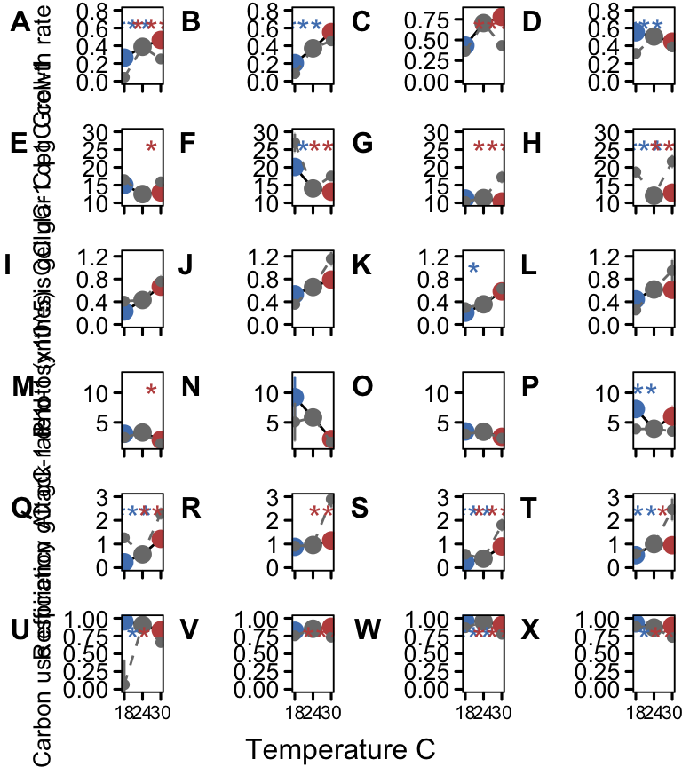

```r
theme_set(theme_base(base_size = 10))
theme_update(plot.background=element_blank())

# 1 growth rate
# 3 c cell
# 0 cue
# 4 resp
# 5 photo
# 6 graz
# 2 chla
# 7 fvfm
#8 N


labelcex <- 10

fig3<-ggarrange(a1, c1, b1,  d1,
                a3, c3, b3, d3,
                a5, c5, b5, d5,
               a6a, c6a, b6a, d6a,
                a4, c4, b4, d4,
                a0, c0, b0, d0,
          labels = c("A", "B", "C","D",
                     "E", "F", "G", "H",
                     "I", "J", "K", "L",
                     "M", "N", "O", "P",
                     "Q", "R", "S", "T",
                     "U", "V", "W", "X"),
          font.label = list(size = 12, color = "black", family = NULL),
          label.x = 0,
          label.y = 1,
          ncol = 4, nrow = 6, align="hv"  )
annotate_figure(fig3, bottom = ("Temperature C"))
```

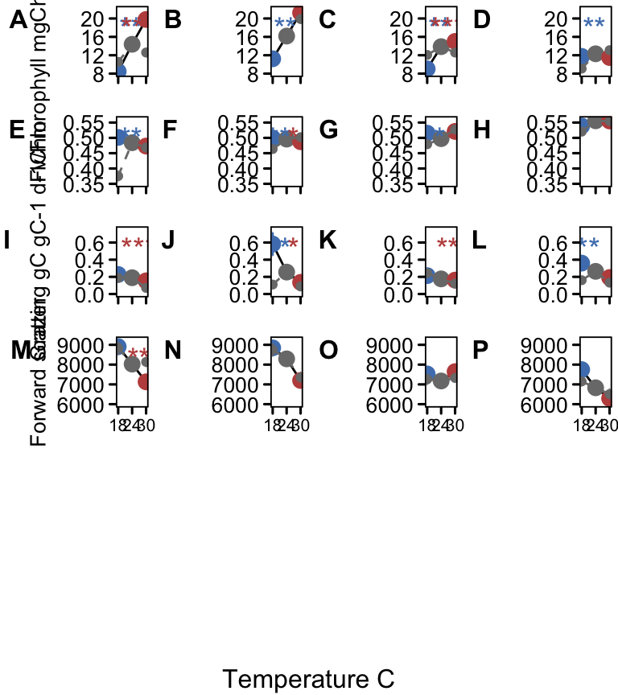

```r
# Figure S4
figs4<- ggarrange(a2, c2, b2, d2,
                  a7, c7, b7, d7,
                  a6, c6, b6, d6,
                  a9, c9, b9, d9,
       labels = c("A", "B", "C", "D",
                  "E", "F", "G", "H",
                  "I", "J", "K", "L",
                  "M", "N", "O", "P"),
   font.label = list(size = 12, color = "black", family = NULL),
          label.x = 0,
          label.y = 1,
          ncol = 4, nrow = 6, align="hv" )
annotate_figure(figs4, bottom = ("Temperature C"))
```

Figure 3. Thermal responses of carbon cycle-relevant traits in mixotrophs. We measured the plastic response of control lineages acclimated to all temperatures (gray points, dotted lines) and the evolved response of experimental lineages at their treatment temperatures (cold-evolved in blue, hot-evolved in red, solid black line). Data for the obligate (Strain 1391, first and second column) and the facultative phototroph (Strain 2951, third and fourth column) are shown for both light levels (high light in first and third column, low light in second and fourth column). Points represent means for all 6 replicates across the final year of the project (2-3 time points) of the experiment, with error bars showing ± 1 standard error. We measured growth rate (A-D), cellular carbon content (E-H), photosynthesis (I-L), attack rate (M-P), respiration (Q-T), and carbon use efficiency (U-X). Significant differences between the evolved and acclimated response at treatment temperatures are shown at the top of each panel in blue for 18°C and red for 30°C (two-sample Student’s t-test; *** = p<0.001, ** = p<0.01, and * = p<0.05).

### 1391 at 100 bar graphs of deltas

```r
# TTEST FOR LOOP for deltas compared to 0
ttest.df.100.2 <- growths100_last3 %>%
  filter(Strain != 1393) %>%
  select( ID, Strain, Ev, Acc, Rep, Week, Growth.del, redf.del, fvfm.del) %>%
  filter(Ev==Acc) %>%
  filter(Ev != 24)
ttest.df.100.2$group <- paste(ttest.df.100.2$Strain,ttest.df.100.2$Ev,ttest.df.100.2$Acc,sep='.')

pvals.df.100.2 <- as.data.frame(unique(ttest.df.100.2$group))
names(pvals.df.100.2) <- 'group'
pvals.df.100.2$Strain <- ttest.df.100.2$Strain[match(pvals.df.100.2$group,ttest.df.100.2$group)]
pvals.df.100.2$Ev <- ttest.df.100.2$Ev[match(pvals.df.100.2$group,ttest.df.100.2$group)]
pvals.df.100.2$Acc <- ttest.df.100.2$Acc[match(pvals.df.100.2$group,ttest.df.100.2$group)]
pvals.df.100.2$p.value.growth <- NA
pvals.df.100.2$p.value.redf <- NA
pvals.df.100.2$p.value.fvfm <- NA
#GR
for(i in 1:dim(pvals.df.100.2)[1]){
  hold <-ttest.df.100.2[ttest.df.100.2$group==pvals.df.100.2$group[i],] %>%
    pull(Growth.del)
  hold.ttest <- t.test(hold)
  tidy.hold <- tidy(hold.ttest)
  pvals.df.100.2$p.value.growth[i] <- round(tidy.hold$p.value,3) }
# REDF
for(i in 1:dim(pvals.df.100.2)[1]){
  hold <-ttest.df.100.2[ttest.df.100.2$group==pvals.df.100.2$group[i],] %>%
    pull(redf.del)
  hold.ttest <- t.test(hold)
  tidy.hold <- tidy(hold.ttest)
  pvals.df.100.2$p.value.redf[i] <- round(tidy.hold$p.value,3) }
#FVFM
for(i in 1:dim(pvals.df.100.2)[1]){
  hold <-ttest.df.100.2[ttest.df.100.2$group==pvals.df.100.2$group[i],] %>%
    pull(fvfm.del)
  hold.ttest <- t.test(hold)
  tidy.hold <- tidy(hold.ttest)
  pvals.df.100.2$p.value.fvfm[i] <- round(tidy.hold$p.value,3) }

## CN
ttest.df.100.cn <- cn.100_last3 %>%
  filter(Strain != 1393) %>%
  select( ID, Strain, Ev, Acc, Rep, Week, C.del, N.del) %>%
  filter(Ev==Acc) %>%
  filter(Ev != 24)
ttest.df.100.cn$group <- paste(ttest.df.100.cn$Strain,ttest.df.100.cn$Ev,ttest.df.100.cn$Acc,sep='.')
pvals.df.100.2$p.value.c <- NA
# C
for(i in 1:dim(pvals.df.100.2)[1]){
  hold <-ttest.df.100.cn[ttest.df.100.cn$group==pvals.df.100.2$group[i],] %>%
    pull(C.del)
  hold.ttest <- t.test(hold)
  tidy.hold <- tidy(hold.ttest)
  pvals.df.100.2$p.value.c[i] <- round(tidy.hold$p.value,3) }

## Resp
ttest.df.100.resp <- resp.100_last3 %>%
  filter(Strain != 1393) %>%
  select( ID, Strain, Ev, Acc, Rep, Week, Resp.del, Photo.del) %>%
  filter(Ev==Acc) %>%
  filter(Ev != 24) %>%
  filter(!is.na(Resp.del))
ttest.df.100.resp$group <- paste(ttest.df.100.resp$Strain,ttest.df.100.resp$Ev,ttest.df.100.resp$Acc,sep='.')
pvals.df.100.2$p.value.resp <- NA
pvals.df.100.2$p.value.photo <- NA
# resp
for(i in 1:dim(pvals.df.100.2)[1]){
  hold <-ttest.df.100.resp[ttest.df.100.resp$group==pvals.df.100.2$group[i],] %>%
    pull(Resp.del)
  hold.ttest <- t.test(hold)
  tidy.hold <- tidy(hold.ttest)
  pvals.df.100.2$p.value.resp[i] <- round(tidy.hold$p.value,3) }
# photo
for(i in 1:dim(pvals.df.100.2)[1]){
  hold <-ttest.df.100.resp[ttest.df.100.resp$group==pvals.df.100.2$group[i],] %>%
    pull(Photo.del)
  hold.ttest <- t.test(hold)
  tidy.hold <- tidy(hold.ttest)
  pvals.df.100.2$p.value.photo[i] <- round(tidy.hold$p.value,3) }

## Attack
ttest.df.100.attack <- attack100_last3 %>%
  filter(Strain != 1393) %>%
  select( ID, Strain, Ev, Acc, Rep, Week, Attack.del) %>%
  filter(Ev==Acc) %>%
  filter(Ev != 24) %>%
  filter(!is.na(Attack.del))
ttest.df.100.attack$group <- paste(ttest.df.100.attack$Strain,ttest.df.100.attack$Ev,ttest.df.100.attack$Acc,sep='.')
pvals.df.100.2$p.value.attack <- NA

# attack
for(i in 1:dim(pvals.df.100.2)[1]){
  hold <-ttest.df.100.attack[ttest.df.100.attack$group==pvals.df.100.2$group[i],] %>%
    pull(Attack.del)
  hold.ttest <- t.test(hold)
  tidy.hold <- tidy(hold.ttest)
  pvals.df.100.2$p.value.attack[i] <- round(tidy.hold$p.value,3) }

## CUE

CUE100_last3_del<- cue.gr.avg.100
CUE100_last3_del$Treat.Acc <- paste(CUE100_last3_del$Strain,CUE100_last3_del$Acc,CUE100_last3_del$Rep,sep='.')

CUE100_hold<-cue.gr.avg.100 %>%
  filter(Ev == 24)
CUE100_hold$Treat.Acc <- paste(CUE100_hold$Strain,CUE100_hold$Acc,CUE100_hold$Rep,sep='.')

CUE100_last3_del$cue.ref <- CUE100_hold$CUE[match(CUE100_last3_del$Treat.Acc,CUE100_hold[CUE100_hold$Ev==24,]$Treat.Acc)]

CUE100_last3_del <- CUE100_last3_del[!is.na(CUE100_last3_del$cue.ref),]

# Match evolved & ancestral reference points
CUE100_last3_del$cue.propdel <- (CUE100_last3_del$CUE-CUE100_last3_del$cue.ref)/abs(CUE100_last3_del$cue.ref) # Compute rel. difference
CUE100_last3_del$cue.del <- (CUE100_last3_del$CUE-CUE100_last3_del$cue.ref) # Compute abs difference

## CUE
ttest.df.100.cue <- CUE100_last3_del %>%
  select( ID, Strain, Ev, Acc, Rep, cue.del) %>%
  filter(Ev==Acc) %>%
  filter(Ev != 24) %>%
  filter(!is.na(cue.del))
ttest.df.100.cue$group <- paste(ttest.df.100.cue$Strain,ttest.df.100.cue$Ev,ttest.df.100.cue$Acc,sep='.')
pvals.df.100.2$p.value.cue <- NA

# cue
for(i in 1:dim(pvals.df.100.2)[1]){
  hold <-ttest.df.100.cue[ttest.df.100.cue$group==pvals.df.100.2$group[i],] %>%
    pull(cue.del)
  hold.ttest <- t.test(hold)
  tidy.hold <- tidy(hold.ttest)
  pvals.df.100.2$p.value.cue[i] <- round(tidy.hold$p.value,3) }


## data frame of significance

pvals.df.100.2.sig <- pvals.df.100.2
pvals.df.100.2.sig[ ,5:12][pvals.df.100.2.sig [,5:12] > .05] <- NA
pvals.df.100.2.sig[ ,5:12][pvals.df.100.2.sig [,5:12] <=.001] <- "high"
pvals.df.100.2.sig[ ,5:12][pvals.df.100.2.sig [,5:12] <=.01] <-"mid"
pvals.df.100.2.sig[ ,5:12][pvals.df.100.2.sig [,5:12] <=.05] <-"low"

pvals.df.100.2.sig[ ,5:12][pvals.df.100.2.sig [,5:12] == "high"] <- "***"
pvals.df.100.2.sig[ ,5:12][pvals.df.100.2.sig [,5:12] =="mid"] <- "**"
pvals.df.100.2.sig[ ,5:12][pvals.df.100.2.sig [,5:12] =="low"] <-  "*"
```

Save plots for bar plot and plot composite fig 4

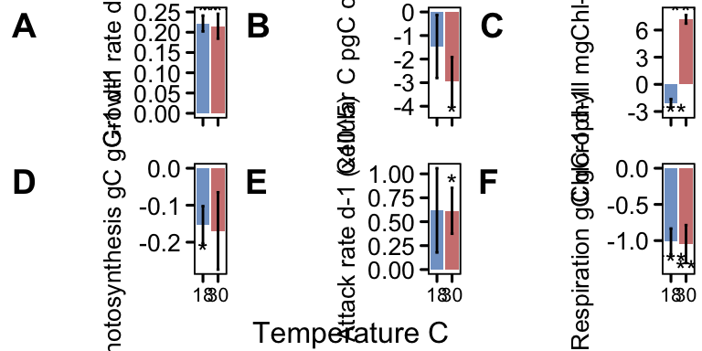

```r
#Growth, C/cell, Chla, ETR, Cfix, Graz, Resp
theme_set(theme_base(base_size = 10))
theme_update(plot.background=element_blank())
# DIFFERENCES

par(mar=c(2,4,2,2),mfcol=c(3,3))
coldhot <- c(lcol,hcol)

growths100_last3.91<-growths100_last3 %>%
  filter(Strain == 1391) %>%
  filter(Ev != 24) %>%
  filter(Acc != 24) %>%
  filter(Ev == Acc)
growths100_last3.91$group <- paste(growths100_last3.91$Strain, growths100_last3.91$Ev,sep=".")

cn.100.91<-cn.100 %>%
  filter(Strain == 1391) %>%
  filter(Ev != 24) %>%
  filter(Acc != 24) %>%
  filter(Ev == Acc)
cn.100.91$group <- paste(cn.100.91$Strain, cn.100.91$Ev,sep=".")

redf.100_last3.91<-growths100_last3.91 %>%
  filter(Strain == 1391) %>%
  filter(Ev != 24) %>%
  filter(Acc != 24) %>%
  filter(Ev == Acc)
redf.100_last3.91$group <- paste(redf.100_last3.91$Strain, redf.100_last3.91$Ev,sep=".")

photopt.100_last3.91<-resp.100_last3%>%
  filter(Strain == 1391) %>%
  filter(Ev != 24) %>%
  filter(Acc != 24) %>%
  filter(Ev == Acc) %>%
  filter(!is.na(Photo.del))
photopt.100_last3.91$group <- paste(photopt.100_last3.91$Strain, photopt.100_last3.91$Ev,sep=".")

attack100_last3.91<-attack100_last3%>%
  filter(Strain == 1391) %>%
  filter(Ev != 24) %>%
  filter(Acc != 24) %>%
  filter(Ev == Acc)
attack100_last3.91$group <- paste(attack100_last3.91$Strain, attack100_last3.91$Ev,sep=".")

resp.100_last3.91<-resp.100_last3%>%
  filter(Strain == 1391) %>%
  filter(Ev != 24) %>%
  filter(Acc != 24) %>%
  filter(Ev == Acc) %>%
  filter(!is.na(Resp.del))
resp.100_last3.91$group <- paste(resp.100_last3.91$Strain, resp.100_last3.91$Ev,sep=".")

growths.91del <- summarySE(data=growths100_last3.91,measurevar='Growth.del',groupvars=c('Strain','Ev','Acc'))
c.91del <- summarySE(data=cn.100.91,measurevar='C.del',groupvars=c('Strain','Ev','Acc'))
redf.91del <- summarySE(data=redf.100_last3.91,measurevar='redf.del',groupvars=c('Strain','Ev','Acc'))
photopt.91del <- summarySE(data=photopt.100_last3.91,measurevar='Photo.del',groupvars=c('Strain','Ev','Acc'))
attack.91del <- summarySE(data=attack100_last3.91,measurevar='Attack.del',groupvars=c('Strain','Ev','Acc'))
resp.91del <- summarySE(data=resp.100_last3.91,measurevar='Resp.del',groupvars=c('Strain','Ev','Acc'))

#pvalues
bar.pvals <- pvals.df.100.2 %>%
  filter(Strain == "1391") %>%
  select( "group", "Ev", "p.value.growth", "p.value.redf","p.value.c", "p.value.resp", "p.value.photo", "p.value.attack")
bar.pvals.sig <- bar.pvals
bar.pvals.sig[ ,3:8][bar.pvals.sig [,3:8] >.05] <- NA

bar.pvals.sig[ ,3:8][bar.pvals.sig [,3:8] <=.001] <- "high"
bar.pvals.sig[ ,3:8][bar.pvals.sig [,3:8] <=.01] <-"mid"
bar.pvals.sig[ ,3:8][bar.pvals.sig [,3:8] <=.05] <-"low"

bar.pvals.sig[ ,3:8][bar.pvals.sig [,3:8] == "high"] <-"***"
bar.pvals.sig[ ,3:8][bar.pvals.sig [,3:8] == "mid"]<-"**"
bar.pvals.sig[ ,3:8][bar.pvals.sig [,3:8] == "low"]<-"*"


labelcex <- 10

p1<-  ggplot(growths.91del, aes(x=as.factor(Ev), y=Growth.del, fill=as.factor(Ev))) +
  geom_bar(stat="identity")  +
  geom_errorbar(aes(ymin=Growth.del-se, ymax=Growth.del+se), width=.2) +
  scale_fill_manual(values=coldhot) +
  theme(legend.position = "none",
        axis.text.x = element_blank(),
         axis.text.y=element_text(size = labelcex),
        axis.ticks.length = unit(.1, "cm"),
        plot.margin = margin(.1, .1, .1, 1.5, "cm")) +
  labs( y = "Growth rate d-1", x=NULL) +
  annotate("text", x= 1,  y = .25, label = bar.pvals.sig[bar.pvals.sig$Ev==18,]$p.value.growth) +
  annotate("text", x= 2,  y = .25, label = bar.pvals.sig[bar.pvals.sig$Ev==30,]$p.value.growth)

p2<-  ggplot(c.91del, aes(x=as.factor(Ev), y=C.del, fill=as.factor(Ev))) +
  geom_bar(stat="identity")  +
  geom_errorbar(aes(ymin=C.del-se, ymax=C.del+se), width=.2) +
  scale_fill_manual(values=coldhot) +
   theme(legend.position = "none",
        axis.text.x = element_blank(),
         axis.text.y=element_text(size = labelcex),
        axis.ticks.length = unit(.1, "cm"),
        plot.margin = margin(.1, .1, .1, 1.5, "cm")) +
  labs( y = "Cellular C pgC cell-1", x=NULL) +
  annotate("text", x= 1,  y = -4.3, label = bar.pvals.sig[bar.pvals.sig$Ev=="18",]$p.value.c)+
  annotate("text", x= 2,  y = -4.3, label = bar.pvals.sig[bar.pvals.sig$Ev=="30",]$p.value.c)

p3<-ggplot(redf.91del, aes(x=as.factor(Ev), y=redf.del, fill=as.factor(Ev))) +
  geom_bar(stat="identity")  +
  geom_errorbar(aes(ymin=redf.del-se, ymax=redf.del+se), width=.2) +
  scale_fill_manual(values=coldhot) +
   theme(legend.position = "none",
        axis.text.x = element_blank(),
         axis.text.y=element_text(size = labelcex),
        axis.ticks.length = unit(.1, "cm"),
        plot.margin = margin(.1, .1, .1, 1.5, "cm")) +
labs( y = "Chlorophyll mgChl-a gC-1", x=NULL) +
  annotate("text", x= 1,  y = -3.2, label = bar.pvals.sig[bar.pvals.sig$Ev=="18",]$p.value.redf) +
  annotate("text", x= 2,  y = 8, label = bar.pvals.sig[bar.pvals.sig$Ev=="30",]$p.value.redf)

p4<-ggplot(photopt.91del, aes(x=as.factor(Ev), y=Photo.del, fill=as.factor(Ev))) +
  geom_bar(position="identity", stat = "identity")  +
  geom_errorbar(aes(ymin=Photo.del-se, ymax=Photo.del+se), width=.2) +
  scale_fill_manual(values=coldhot) +
   theme(legend.position = "none",
       # axis.text.x = element_blank(),
         axis.text.y=element_text(size = labelcex),
        axis.ticks.length = unit(.1, "cm"),
        plot.margin = margin(.1, .1, .1, 1.5, "cm")) +
  labs( y = "Photosynthesis gC gC-1 d-1", x=NULL) +
  annotate("text", x= 1,  y = -.225, label = bar.pvals.sig[bar.pvals.sig$Ev=="18",]$p.value.photo) +
  annotate("text", x= 2,  y = -.225, label = bar.pvals.sig[bar.pvals.sig$Ev=="30",]$p.value.photo)

p5<-ggplot(attack.91del, aes(x=as.factor(Ev), y=Attack.del, fill=as.factor(Ev))) +
  geom_bar(stat="identity")  +
  geom_errorbar(aes(ymin=Attack.del-se, ymax=Attack.del+se), width=.2) +
  scale_fill_manual(values=coldhot) +
   theme(legend.position = "none",
       # axis.text.x = element_blank(),
        axis.text.y=element_text(size = labelcex),
        axis.ticks.length = unit(.1, "cm"),
        plot.margin = margin(.1, .1, .1, 1.5, "cm")) +
 labs( y = "Attack rate d-1 (x10^5)", x=NULL)  +
  annotate("text", x= 1,  y = .9, label = bar.pvals.sig[bar.pvals.sig$Ev=="18",]$p.value.attack) +
  annotate("text", x= 2,  y = .9, label = bar.pvals.sig[bar.pvals.sig$Ev=="30",]$p.value.attack)

p6<-ggplot(resp.91del, aes(x=as.factor(Ev), y=Resp.del, fill=as.factor(Ev))) +
  geom_bar(stat="identity", position = "identity")  +
  geom_errorbar(aes(ymin=Resp.del-se, ymax=Resp.del+se), width=.2) +
  scale_fill_manual(values=coldhot) +
  theme(legend.position = "none",
        #axis.text.x = element_blank(),
         axis.text.y=element_text(size = labelcex),
        axis.ticks.length = unit(.1, "cm"),
        plot.margin = margin(.1, .1, .1, 1.5, "cm")) +
  labs( y = "Respiration gC gC-1 d-1", x=NULL) +
  annotate("text", x= 1,  y = -1.3, label = bar.pvals.sig[bar.pvals.sig$Ev=="18",]$p.value.resp) +
  annotate("text", x= 2,  y = -1.4, label = bar.pvals.sig[bar.pvals.sig$Ev=="30",]$p.value.resp)

fig4<- ggarrange(p1,p2,p3,
          p4,p5,p6,
         labels = c("A", "B", "C",
                    "D", "E", "F"),
          nrow = 2, ncol = 3, align = "hv")
annotate_figure(fig4, bottom = "Temperature C")
```

Figure 4. Differences between evolved and plastic responses of obligate phototroph at high light. Differences between evolved responses of the cold and warm evolved lineages and the plastic responses of the acclimated controls at the respective cold and warm temperatures (obtained from reciprocal transplant) are shown for several key traits, to examine what mechanisms drove adaptation in the obligate phototroph (Strain 1391) at high light (100 μmol quanta·m−2·s−1). The differences in cold-evolved lineages and acclimated controls are shown in blue, and the differences in hot-evolved lineages and acclimated controls is shown in red. Data are averaged for all 6 replicates across the last year of the experiment (2-3 time points) with error bars showing +/- 1 standard error. We measured growth rate (panel A), cellular C content (panel B), chlorophyll (panel C), photosynthesis (panel D), attack rate (panel E), and respiration (panel F). Significant differences are shown by each bar (one-sample Student’s t-test; *** = p<0.001, ** = p<0.01, and * = p<0.05).

Calculate delta values

```r
# calculate percent changes and name

#growth
del.gr.18 <- growths100_last3.91 %>%
  filter(Ev == 18) %>%
  pull(Growth.del) %>%
  mean
del.gr.30 <- growths100_last3.91 %>%
  filter(Ev == 30) %>%
  pull(Growth.del) %>%
  mean
val.gr.30 <- growths100_last3 %>%
  filter(Ev == 24 & Acc == 30) %>%
  filter(Strain == 1391) %>%
  pull(Growth.Rate) %>%
  mean
val.gr.18 <- growths100_last3 %>%
  filter(Ev == 24 & Acc == 18) %>%
  filter(Strain == 1391) %>%
  pull(Growth.Rate) %>%
  mean

del.redf.18 <- growths100_last3.91 %>%
  filter(Ev == 18) %>%
  pull(redf.del) %>%
  mean
del.redf.30 <- growths100_last3.91 %>%
  filter(Ev == 30) %>%
  pull(redf.del) %>%
  mean
val.redf.30 <- growths100_last3 %>%
  filter(Ev == 24 & Acc == 30) %>%
  filter(Strain == 1391) %>%
  pull(redf) %>%
  mean
val.redf.18 <- growths100_last3 %>%
  filter(Ev == 24 & Acc == 18) %>%
  filter(Strain == 1391) %>%
  pull(redf) %>%
  mean

#C
del.C.18 <- cn.100.91 %>%
  filter(Ev == 18) %>%
  pull(C.del) %>%
  mean
del.C.30 <- cn.100.91 %>%
  filter(Ev == 30) %>%
  pull(C.del) %>%
  mean
val.C.30 <- cn.100_last3 %>%
  filter(Ev == 24 & Acc == 30) %>%
  filter(Strain == 1391) %>%
  pull(C) %>%
  mean
val.C.18 <- cn.100_last3 %>%
  filter(Ev == 24 & Acc == 18) %>%
  filter(Strain == 1391) %>%
  pull(C) %>%
  mean

#attack
del.attack.18 <- attack100_last3.91 %>%
  filter(Ev == 18) %>%
  pull(Attack.del) %>%
  mean
del.attack.30 <- attack100_last3.91 %>%
  filter(Ev == 30) %>%
  pull(Attack.del) %>%
  mean
val.attack.30 <- attack100_last3 %>%
  filter(Ev == 24 & Acc == 30) %>%
  filter(Strain == 1391) %>%
  pull(attack) %>%
  mean
val.attack.18 <- attack100_last3 %>%
  filter(Ev == 24 & Acc == 18) %>%
  filter(Strain == 1391) %>%
  pull(attack) %>%
  mean

#Resp/photo
del.resp.18 <- resp.100_last3.91 %>%
  filter(Ev == 18) %>%
  pull(Resp.del) %>%
  mean
del.resp.30 <- resp.100_last3.91 %>%
  filter(Ev == 30) %>%
  pull(Resp.del) %>%
  mean
val.resp.30 <- resp.100_last3 %>%
  filter(Ev == 24 & Acc == 30) %>%
  filter(Strain == 1391) %>%
  pull(Resp) %>%
  mean
val.resp.18 <- resp.100_last3 %>%
  filter(Ev == 24 & Acc == 18) %>%
  filter(Strain == 1391) %>%
  pull(Resp) %>%
  mean

del.photo.18 <- resp.100_last3.91 %>%
  filter(Ev == 18) %>%
  pull(Photo.del) %>%
  mean
del.photo.30 <- resp.100_last3.91 %>%
  filter(Ev == 30) %>%
  pull(Photo.del) %>%
  mean
val.photo.30 <- resp.100_last3 %>%
  filter(Ev == 24 & Acc == 30) %>%
  filter(Strain == 1391) %>%
  pull(Photo) %>%
  mean
val.photo.18 <- resp.100_last3 %>%
  filter(Ev == 24 & Acc == 18) %>%
  filter(Strain == 1391) %>%
  pull(Photo) %>%
  mean

hotc  <- abs(del.C.30 /val.C.30) *100

hotattack <- abs(del.attack.30  /val.attack.30) * 100

hotresp <- abs(del.resp.30 / val.resp.30) *100

coldresp<- abs(del.resp.18 / val.resp.18) *100

hotc
```

```
## [1] 18.55166
```

```r
hotattack
```

```
## [1] 42.87443
```

```r
hotresp
```

```
## [1] 45.89874
```

```r
coldresp
```

```
## [1] 80.46144
```

### THERMAL RESPONSE CURVES

```r
#upload thermal response data

pe <- read_csv(here::here("data","pestats_trc_rev3.csv"))
graz <- read_csv(here::here("data","TRC_grazstats_dilution_rev3.csv"))

# grazing pgC per och per day (bact per och per day * C per bact * fg to pgC * 24hrs)
graz$graz.day <- graz$G_O *24 * 113.5996283 * 0.001
#new
graz$g.alpha.day <- graz$a.bestfit *24
graz$g.alpha.day.2 <-graz$a.bestfit *24 *10^5

pe$ID.Ev <- paste(pe$Strain,pe$Ev,pe$Rep,sep='.')
graz$ID.Ev <- paste(graz$Strain,graz$Ev,graz$Rep,sep='.')

dat100<- read_csv(here::here("data","OECD100_rev3.csv"))
dat100$ID.Ev <- paste(dat100$Strain,dat100$Ev,dat100$Rep,sep='.')
hold1 <- dat100 %>%
  filter(Strain == 1391) %>%
  filter(Week == 154) %>%
  filter(Ev == Acc)
hold1$Mean.redF <- (hold1$Day1.redF + hold1$Day2.redF + hold1$Day3.redF + hold1$Day4.redF) / 4
hold1$redF.corr <- (2.732e-05)*(hold1$Mean.redF) + (6.702e-03)
pe$redF.corr <- hold1$redF.corr[match(pe$ID.Ev,hold1$ID.Ev)]

hold2 <- dat100 %>%
  filter(Strain == 1391) %>%
  filter(Week == 141) %>%
  filter(Ev == Acc)
pe$pgC.cell <- hold2$pgC.cell[match(pe$ID.Ev,hold2$ID.Ev)]
graz$pgC.cell <-hold2$pgC.cell[match(graz$ID.Ev,hold2$ID.Ev)]

pe$Treat <- paste(pe$Strain,pe$Ev,pe$Assay,sep='.')
graz$Treat <- paste(graz$Strain,graz$Ev,graz$Acc,sep='.')

graz$graz.C.day <- graz$graz.day / graz$pgC.cell

# ETR is in units of electrons per second. Multiplying by per conversion multiplier (0.06332817) and C:CO2 ratio (12/44) and pgChla/cell results in units of pgC fixed per cell per day. Divide by pgC/cell again to get pgC/pgC/day

#pgC per cell per day = ETR * chla(W154redf) * multiplier *12

pe$cfix <- pe$P_I.interp * pe$redF.corr * 0.06332817 * 12 *(12/44)

#pgC per pgC per day = cfix / C/cell

pe$cfixperc <- ( pe$P_I.interp * pe$redF.corr * 0.06332817 * 12 *(12/44) ) / pe$pgC.cell

#electrons per pgC per day
#### copy notes from notebook on how you got is conversion!!!

pe$eperc <- pe$P_I.interp * 0.002 * 6.02e+23 * 0.001119183 * 0.000000001 *60 *60 *12 * (1/pe$redF.corr) * (1/pe$pgC.cell)

ev_cols <- c("18" = lcol2, "24" = mcol2, "30" = hcol2)
```

Photosynthetic capacity using “growthTools” First, each temperature separately Average all reps at each temp with confidence intervals electrons per pgC per day

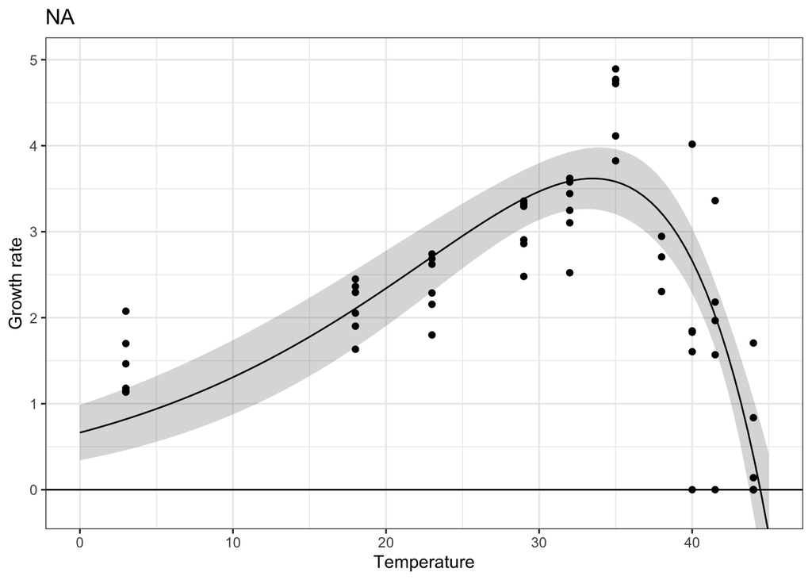

```r
# calculate each temperature separately

# divide by 10^15 to make units nicer, add this back in in the axis label
pe$eperc2 <- pe$eperc / 10^15

#   Single  data    set:
new.grids<-list(topt=seq(20,40,5),w=seq(10,40,5),a=seq(1,-1,-0.5),b=c(-0.05,0,0.05))
new.start<-list(topt=NA,w=NA,a=NA,b=NA,s=log(2))

sp1_pi3 <- pe   %>%
  filter(Ev == "18")
nbcurve.traits_pi3  <- get.nbcurve.tpc(sp1_pi3$Assay,   sp1_pi3$eperc2, method  =
"grid.mle2", grids=new.grids,start=new.start)

sp2_pi3 <- pe   %>%
  filter(Ev == "24")
nbcurve.traits2_pi3 <- get.nbcurve.tpc(sp2_pi3$Assay,   sp2_pi3$eperc2, method  =
"grid.mle2", grids=new.grids,start=new.start)

sp3_pi3 <- pe   %>%
  filter(Ev == "30")
nbcurve.traits3_pi3 <- get.nbcurve.tpc(sp3_pi3$Assay,   sp3_pi3$eperc2, method  =
"grid.mle2", grids=new.grids,start=new.start)

plot(nbcurve.traits_pi3,xlim=c(0,45))
```

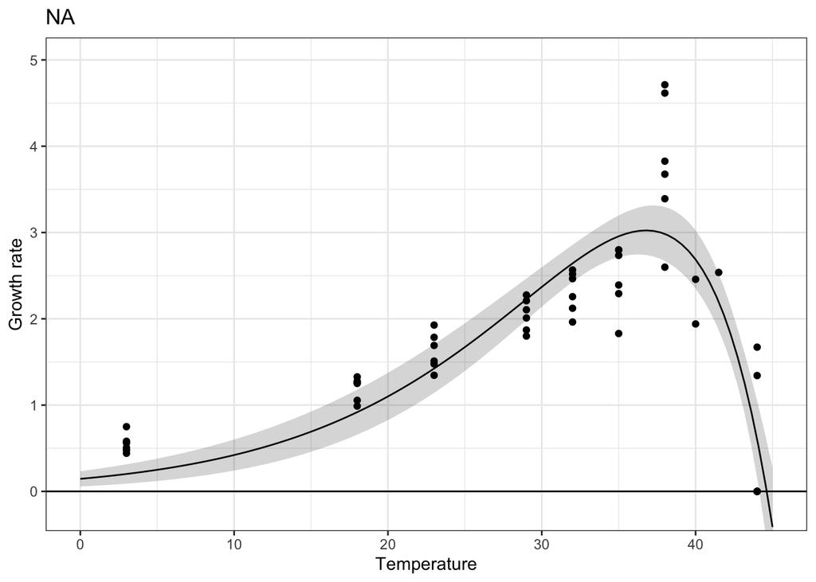

```r
plot(nbcurve.traits2_pi3,xlim=c(0,45))
```

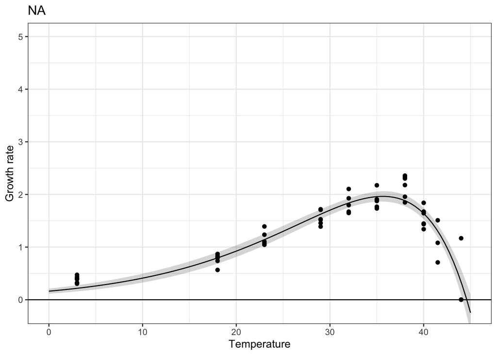

```r
plot(nbcurve.traits3_pi3,xlim=c(0,45))
```

```r
nbcurve.traits_pi3$topt
```

```
## [1] 33.50662
```

```r
nbcurve.traits2_pi3$topt
```

```
## [1] 36.78505
```

```r
nbcurve.traits3_pi3$topt
```

```
## [1] 35.64262
```

```r
nbcurve.traits_pi3$tmax
```

```
## [1] 44.45377
```

```r
nbcurve.traits2_pi3$tmax
```

```
## [1] 44.62345
```

```r
nbcurve.traits3_pi3$tmax
```

```
## [1] 44.60222
```

Then temp by color on same plot with confidence intervals, topt, and tmax Grouped by temp with confidence intervals e^-1 per pgC

Plot figure 5A

```r
#Predict values from a tpc
tmp18_pi3   <- predict(nbcurve.traits_pi3,  se.fit  =   T, newdata = data.frame(temperature=seq(0,45,0.1)))
tmp24_pi3 <- predict(nbcurve.traits2_pi3,   se.fit  =   T, newdata = data.frame(temperature=seq(0,45,0.1)))
tmp30_pi3 <- predict(nbcurve.traits3_pi3,   se.fit  =   T, newdata = data.frame(temperature=seq(0,45,0.1)))

theme_set(theme_base(base_size = 10))
theme_update(plot.background=element_blank())

#   plot    the predictions
  fig5a<- ggplot(tmp18_pi3, aes(x   =   temperature,    y   =   mu))    +
    geom_ribbon(aes(ymin    =   mu  - 1.96 * se.fit,    ymax    =   mu  + 1.96 * se.fit),
                fill    = newcols[1],alpha =.4) +
    geom_line(color =newcols[1] )   +
    coord_cartesian(xlim = c(0,50),ylim = c(-.2,    4.5))   +
    scale_x_continuous("")  + scale_y_continuous("Electron transport rate e-1 pgC-1 day-1 (x10^15)")    +
    geom_hline(yintercept = 0)+
    geom_ribbon(data = tmp24_pi3, aes(ymin  =   mu  -   1.96 * se.fit,  ymax    =   mu  + 1.96 * se.fit),
                fill    = newcols[2],alpha =.4) +
    geom_line(data = tmp24_pi3, color = newcols[2]) +
    geom_ribbon(data = tmp30_pi3, aes(ymin  =   mu  - 1.96 * se.fit,    ymax    =   mu  + 1.96 * se.fit),
                fill    = newcols[3],alpha =.4) +
    geom_line(data = tmp30_pi3, color = newcols[3]) +
    geom_vline(xintercept   = nbcurve.traits_pi3$topt, color = newcols[1])  +
    geom_vline(xintercept   = nbcurve.traits2_pi3$topt, color = newcols[2]) +
    geom_vline(xintercept   = nbcurve.traits3_pi3$topt, color = newcols[3]) +
    geom_vline(xintercept   = nbcurve.traits_pi3$tmax, color = newcols[1] ) +
    geom_vline(xintercept   = nbcurve.traits2_pi3$tmax, color = newcols[2]) +
    geom_vline(xintercept   = nbcurve.traits3_pi3$tmax, color = newcols[3]) +
    geom_point(data =   sp1_pi3, aes(x = Assay, y = eperc2),    color = lcol2,alpha = 0.4) +
     geom_point(data    =   sp2_pi3, aes(x = Assay, y = eperc2),    color = "grey",alpha    = 0.4) +
     geom_point(data    =   sp3_pi3, aes(x = Assay, y = eperc2),    color = hcol2,alpha = 0.4) +
    theme(legend.position = "none",
          axis.text.y=element_text(size = 11),
          axis.text.x=element_text(size = 11),
          axis.ticks.length = unit(.1, "cm"))
```

Smooth spline for fvfm and grazing

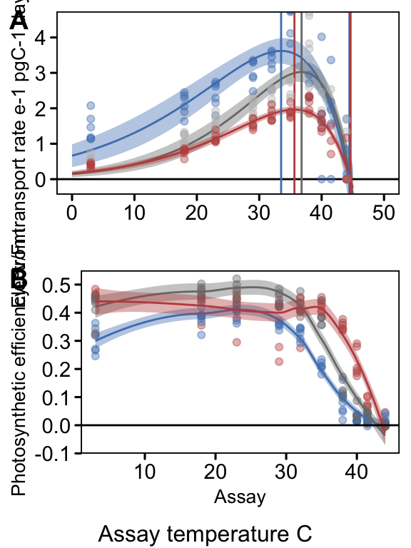

```r
# geom smooth using loess and default span of .75
 fig5b<-  ggplot(pe, aes(x = Assay, y = Fv.Fm)) +
  geom_point(aes(color = as.factor(Ev)), alpha = .4) +
               scale_color_manual(values = newcols)+
   geom_smooth(aes(x = Assay, y = Fv.Fm, color = as.factor(Ev),fill = as.factor(Ev)), alpha = .4, method = "loess", span = .75, size = .5) +
     scale_fill_manual(values = newcols) +
  geom_hline(yintercept = 0)+
theme(legend.position = "none",
        axis.text.y=element_text(size = 11),
        axis.text.x=element_text(size = 11),
        axis.ticks.length = unit(.1, "cm")) +
  labs(y = "Photosynthetic efficiency Fv/Fm")

fig5<-ggarrange(fig5a, fig5b,
                labels = c("A", "B"),
                nrow = 2, ncol = 1,
                widths = 1,
                heights = 1)
  annotate_figure(fig5, bottom = "Assay temperature C")
```

Figure 5. Thermal response curves of two photosynthetic traits for obligate phototroph at high light. Electron transport rate per pgC (panel A) and photosynthetic efficiency (panel B) were measured at 10 temperatures between 3°C and 44°C for cold-evolved (blue), control (gray), and hot-evolved (red) lineages at the termination of the evolution experiment. For the cold-evolved lineages this represents >200 generations, and for the hot-evolved lineages, this represents >600 generations. Curves with confidence intervals represent the average of all 6 lineages at each temperature and individual lineages are represented by points. Three vertical lines farthest to the left represent the thermal optimum of each temperature, while the vertical lines on the right represent the thermal maxima.

Figure S5

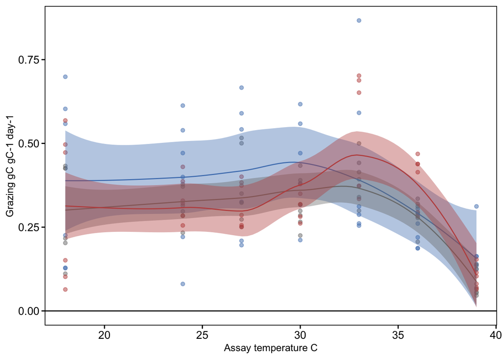

```r
#grazing
   ggplot(graz, aes(x = Assay, y = graz.C.day)) +
  geom_point(aes(color = as.factor(Ev)), alpha = .5, size = 1.5) +
               scale_color_manual(values = newcols)+
   geom_smooth(aes(x = Assay, y = graz.C.day, color = as.factor(Ev),fill = as.factor(Ev)),alpha = .4, method = "loess", span = .75, size = .5) +
     scale_fill_manual(values = newcols) +
     geom_hline(yintercept = 0)+
     theme(legend.position = "none",
        axis.text.y=element_text(size = 11),
        axis.text.x=element_text(size = 11),
        axis.ticks.length = unit(.1, "cm")) +
  labs(x = "Assay temperature C", y = "Grazing gC gC-1 day-1")
```

### Supporting Information

Figure S3 all growth rates from back transfer experiments

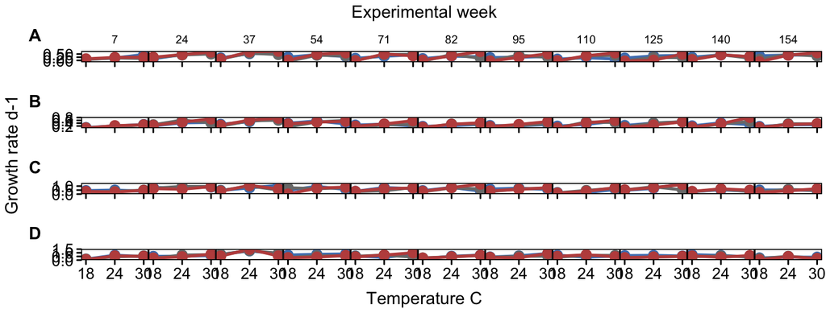

```r
growths100 <-growths100 %>%
  filter(Strain!= 1393)
Growth.summ.100.time <- summarySE(data=growths100,measurevar='Growth.Rate',groupvars=c('Strain','Ev','Acc','Week'))
redf.corr.summ.100.time <- summarySE(data=growths100,measurevar='redf.corr',groupvars=c('Strain','Ev','Acc','Week'))

Growth.summ.100.1391.time <- Growth.summ.100.time %>%
  filter(Strain == 1391)
Growth.summ.100.2951.time <- Growth.summ.100.time %>%
  filter(Strain == 2951)
redf.corr.summ.100.1391.time <- redf.corr.summ.100.time %>%
  filter(Strain == 1391)
redf.corr.summ.100.2951.time <- redf.corr.summ.100.time %>%
  filter(Strain == 2951)

growths50 <-growths50 %>%
  filter(Strain!= 1393)
Growth.summ.50.time <- summarySE(data=growths50,measurevar='Growth.Rate',groupvars=c('Strain','Ev','Acc','Week'))
redf.corr.summ.50.time <- summarySE(data=growths50,measurevar='redf.corr',groupvars=c('Strain','Ev','Acc','Week'))

Growth.summ.50.1391.time <- Growth.summ.50.time %>%
  filter(Strain == 1391)
Growth.summ.50.2951.time <- Growth.summ.50.time %>%
  filter(Strain == 2951)
redf.corr.summ.50.1391.time <- redf.corr.summ.50.time %>%
  filter(Strain == 1391)
redf.corr.summ.50.2951.time <- redf.corr.summ.50.time %>%
  filter(Strain == 2951)


theme_set(theme_base(base_size = 10))
theme_update(plot.background=element_blank())


s1.1<- ggplot(Growth.summ.100.1391.time,
       aes(x=Acc, y=Growth.Rate, color=as.factor(Ev))) +
    geom_errorbar(aes(ymin=Growth.Rate-se, ymax=Growth.Rate+se), width=1) +
    geom_line(lwd = 1) +
    geom_point(size = 3)+
   facet_grid(cols = vars(Week)) +
    scale_color_manual(values=newcols) +
    scale_x_continuous(limits = c(17,31),
                     breaks = c(18,24,30),
                     expand = c(0,0)) +
  scale_y_continuous(expand = c(0,0)) +
    theme(legend.position = "none" ) + #,
         # strip.text = element_blank()) +
    theme(axis.title.x=element_blank(),
        axis.title.y=element_blank(),
        axis.text.x=element_blank(),
        axis.text.y=element_text(size = 11),
        axis.ticks.length = unit(.1, "cm") ,
    panel.spacing = unit(0,'lines'),
        plot.margin = margin(.1, .1, -.2, .5, "cm"))

s1.2<- ggplot(Growth.summ.50.1391.time,
       aes(x=Acc, y=Growth.Rate, color=as.factor(Ev))) +
    geom_errorbar(aes(ymin=Growth.Rate-se, ymax=Growth.Rate+se), width=1) +
    geom_line(lwd = 1) +
    geom_point(size = 3)+
   facet_grid(cols = vars(Week)) +
    scale_color_manual(values=newcols) +
    scale_x_continuous(limits = c(17,31),
                     breaks = c(18,24,30),
                     expand = c(0,0)) +
  scale_y_continuous(expand = c(0,0)) +
    theme(legend.position = "none",
          strip.text = element_blank()) +
  theme(axis.title.x=element_blank(),
        axis.title.y=element_blank(),
        axis.text.x=element_blank(),
        axis.text.y=element_text(size = 11),
        axis.ticks.length = unit(.1, "cm") ,
    panel.spacing = unit(0,'lines'),
        plot.margin = margin(.1, .1, -.2, .5, "cm"))

s1.3<- ggplot(Growth.summ.100.2951.time,
       aes(x=Acc, y=Growth.Rate, color=as.factor(Ev))) +
    geom_errorbar(aes(ymin=Growth.Rate-se, ymax=Growth.Rate+se), width=1) +
    geom_line(lwd = 1) +
    geom_point(size = 3)+
   facet_grid(cols = vars(Week)) +
    scale_color_manual(values=newcols) +
    scale_x_continuous(limits = c(17,31),
                     breaks = c(18,24,30),
                     expand = c(0,0)) +
  scale_y_continuous(expand = c(0,0)) +
    theme(legend.position = "none",
          strip.text = element_blank()) +
  theme(axis.title.x=element_blank(),
        axis.text.x=element_blank(),
        axis.title.y=element_blank(),
        axis.ticks.length = unit(.1, "cm") ,
        axis.text.y=element_text(size = 11),
    panel.spacing = unit(0,'lines'),
        plot.margin = margin(.1, .1, -.2, .5, "cm"))

s1.4<- ggplot(Growth.summ.50.2951.time,
       aes(x=Acc, y=Growth.Rate, color=as.factor(Ev))) +
    geom_errorbar(aes(ymin=Growth.Rate-se, ymax=Growth.Rate+se), width=1) +
    geom_line(lwd = 1) +
    geom_point(size = 3)+
   facet_grid(cols = vars(Week)) +
    scale_color_manual(values=newcols) +
    scale_x_continuous(limits = c(17,31),
                     breaks = c(18,24,30),
                     expand = c(0,0)) +
  scale_y_continuous(expand = c(0,0)) +
    theme(legend.position = "none",
          strip.text = element_blank()) +
  theme(axis.title.x=element_blank(),
        axis.title.y=element_blank(),
        axis.ticks.length = unit(.1, "cm") ,
        axis.text.y=element_text(size = 11),
        axis.text.x=element_text(size = 11),
    panel.spacing = unit(0,'lines'),
        plot.margin = margin(.1, .1, .1, .5, "cm"))


# order 1391 100, 1391 50, 2951 100, 2951 50

figs3<-ggarrange(s1.1, s1.2, s1.3,s1.4,
   labels = c("A", "B", "C","D"),
   font.label = list(size = 12, color = "black", family = NULL),
          label.x = 0,
          label.y = 1,
          ncol = 1, nrow = 4,align="hv" )
annotate_figure(figs3, bottom = "Temperature C", top = "Experimental week", left = "Growth rate d-1")
```

```r
# ggarrange(s1.1, s1.2,
#    labels = c("A", "B"),
#    font.label = list(size = 12, color = "black", family = NULL),
#           label.x = 0,
#           label.y = 1,
#           ncol = 1, nrow = 2,align="hv" )
# ggarrange(s1.3,s1.4,
#    labels = c("C","D"),
#    font.label = list(size = 12, color = "black", family = NULL),
#           label.x = 0,
#           label.y = 1,
#           ncol = 1, nrow = 2,align="hv" )
```

Figure S3. Thermal reaction norms of growth rate for all lineages at every reciprocal transplant time point. Panel A shows the obligate phototroph at high light and panel B at low light. Panel C is the facultative phototroph at high light and panel D at low light. Each box is a single time point labeled as experimental week going from left to right, with the x-axis of each box showing temperature. Blue points and lines are cold-evolved linages, red points and lines are hot-evolved lineages, and gray points and lines are control lineages. All points are averages of 6 replicates with bars depicting standard error.

Figure S2. QAQC showing correlation from extracted chl-a to redf

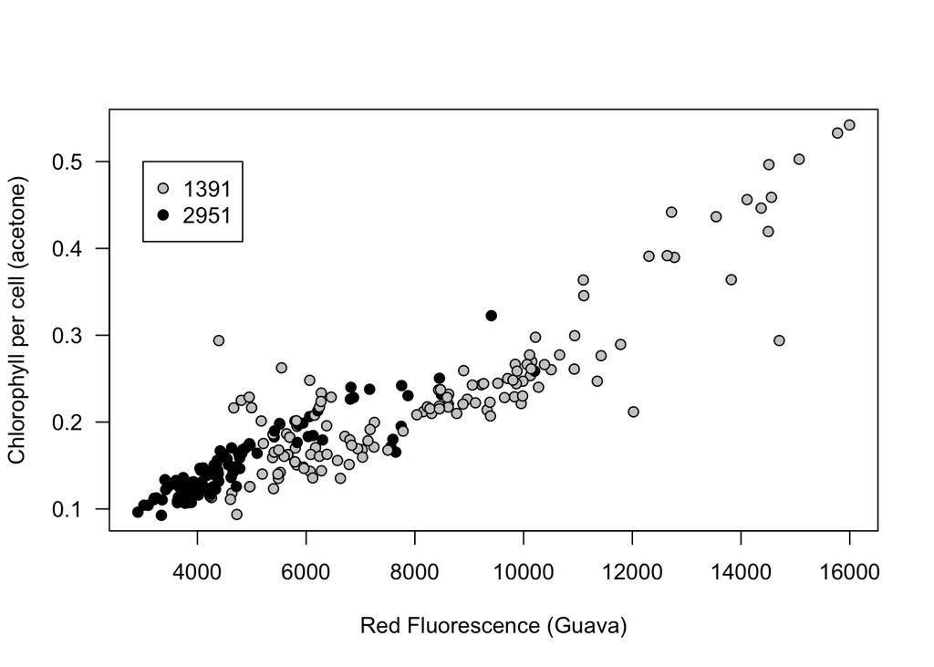

```r
qaqc<-read_csv(here::here("data","QAQC_data_Jan2021 - Export data_rev3.csv"))

plot(qaqc$RedF,qaqc$ChlperCell,pch=21,bg=c('gray80','black')[as.factor(qaqc$Strain)],xlab='Red Fluorescence (Guava)',ylab='Chlorophyll per cell (acetone)',las=1)
legend(3000,.5,pch=21,pt.bg=c('gray80','black'),legend=c('1391','2951'))
```

```r
lm.redF.91 <- lm(ChlperCell~RedF,data=qaqc[qaqc$Strain==1391,])
summary(lm.redF.91)
```

```
##
## Call:
## lm(formula = ChlperCell ~ RedF, data = qaqc[qaqc$Strain == 1391,
##     ])
##
## Residuals:
##      Min       1Q   Median       3Q      Max
## -0.12184 -0.02598 -0.01354  0.02510  0.16773
##
## Coefficients:
##              Estimate Std. Error t value Pr(>|t|)
## (Intercept) 6.633e-03  1.136e-02   0.584     0.56
## RedF        2.720e-05  1.307e-06  20.819   <2e-16 ***
## ---
## Signif. codes:  0 '***' 0.001 '**' 0.01 '*' 0.05 '.' 0.1 ' ' 1
##
## Residual standard error: 0.04388 on 136 degrees of freedom
##   (42 observations deleted due to missingness)
## Multiple R-squared:  0.7612, Adjusted R-squared:  0.7594
## F-statistic: 433.4 on 1 and 136 DF,  p-value: < 2.2e-16
```

```r
lm.redF.51 <- lm(ChlperCell~RedF,data=qaqc[qaqc$Strain==2951,])
summary(lm.redF.51)
```

```
##
## Call:
## lm(formula = ChlperCell ~ RedF, data = qaqc[qaqc$Strain == 2951,
##     ])
##
## Residuals:
##      Min       1Q   Median       3Q      Max
## -0.06139 -0.01034 -0.00092  0.01224  0.04949
##
## Coefficients:
##              Estimate Std. Error t value Pr(>|t|)
## (Intercept) 2.575e-02  5.485e-03   4.694 7.64e-06 ***
## RedF        2.629e-05  1.117e-06  23.536  < 2e-16 ***
## ---
## Signif. codes:  0 '***' 0.001 '**' 0.01 '*' 0.05 '.' 0.1 ' ' 1
##
## Residual standard error: 0.01704 on 112 degrees of freedom
##   (66 observations deleted due to missingness)
## Multiple R-squared:  0.8318, Adjusted R-squared:  0.8303
## F-statistic: 553.9 on 1 and 112 DF,  p-value: < 2.2e-16
```

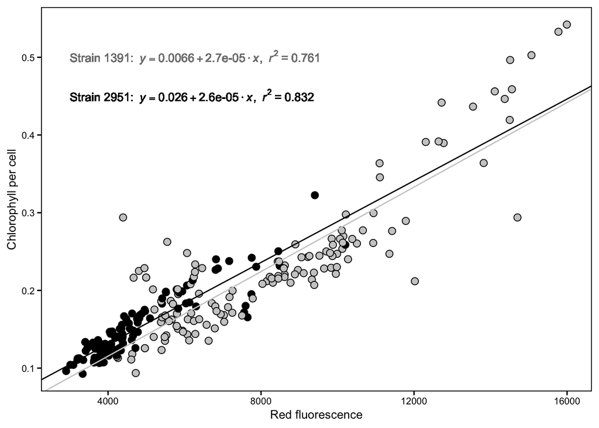

```r
lm.91<-qaqc %>%
  filter(Strain == "1391")

lm_eqn91 <- function(lm.91){
    m <- lm(ChlperCell ~ RedF, lm.91);
    eq <- substitute("Strain 1391:"~~italic(y) == a + b %.% italic(x)*","~~italic(r)^2~"="~r2,
         list(a = format(unname(coef(m)[1]), digits = 2),
              b = format(unname(coef(m)[2]), digits = 2),
             r2 = format(summary(m)$r.squared, digits = 3)))
    as.character(as.expression(eq));
}
lm.51<-qaqc %>%
  filter(Strain == "2951")

lm_eqn51 <- function(lm.51){
    m <- lm(ChlperCell ~ RedF, lm.51);
    eq <- substitute("Strain 2951:"~~italic(y) == a + b %.% italic(x)*","~~italic(r)^2~"="~r2,
         list(a = format(unname(coef(m)[1]), digits = 2),
              b = format(unname(coef(m)[2]), digits = 2),
             r2 = format(summary(m)$r.squared, digits = 3)))
    as.character(as.expression(eq));
}

ggplot(qaqc, aes(x = RedF, y = ChlperCell, fill = as.factor(Strain)))+
  geom_point(size = 2.5, shape = 21) +
  scale_fill_manual(values = c("gray80","black")) +
  geom_abline(intercept = coefficients(lm.redF.91)[1], slope = coefficients(lm.redF.91)[2], color = "gray80") +
  geom_abline(intercept = coefficients(lm.redF.51)[1], slope = coefficients(lm.redF.51)[2], color = "black")  +
theme(legend.position = "NONE",
       axis.ticks.length = unit(.10, "cm")) +
labs( y ="Chlorophyll per cell", x="Red fluorescence") +
   geom_text(x = 3000, y = .5, label = lm_eqn91(lm.91), parse = TRUE, color = "gray50", hjust = "left", size = 3.5)+
  geom_text(x = 3000, y = .45, label = lm_eqn51(lm.51), parse = TRUE, hjust= "left", size = 3.5)
```

Figure S2. Correlation between extracted chlorophyll per cell measurements from a fluorometer and red fluorescence from flow cytometer for each strain of Ochromonas (obligate phototroph Strain 1391 in gray, and facultative phototroph Strain 2951 in black).